[figure not shown]

# Advanced Graphics and Data Visualization in R

# Lecture 03: `ggplot2` and adding those finishing touches

## 0.1.0 An overview of Advanced Graphics and Data Visualization in R

**"Advanced Graphics and Data Visualization in R"** is brought to you by the Centre for the Analysis of Genome Evolution & Function's (CAGEF) bioinformatics training initiative. This CSB1021 was developed to enhance the skills of students with basic backgrounds in R by focusing on available philosophies, methods, and packages for plotting scientific data. While the datasets and examples used in this course will be centred on SARS-CoV-2 epidemiological and genomic data, the lessons learned herein will be broadly applicable.

This lesson is the third in a 6-part series. The aim for the end of this series is for students to recognize how to import, format, and display data based on their intended message and audience. The format and style of these visualizations will help to identify and convey the key message(s) from their experimental data.

The structure of the class is a **code-along style** in Jupyter notebooks. At the start of each lecture, skeleton versions of the lecture will be provided for use on the [University of Toronto Jupyter Hub](https://jupyter.utoronto.ca/hub/login) so students can program along with the instructor.

## 0.2.0 Lecture objectives

Last week we did a deep dive on some of the more popular and broadly applicable visualizations for conveying basic ideas about your data. This week will focus on tidying up your visualizations and adding those extra finishing touches that will help polish them off. Adding, removing, altering graphs. Getting these little details correct help you to avoid alterations with additional software outside of R.

At the end of this lecture you will have covered the following topics

1. Altering and reproducing themes.
2. Setting and changing the content of titles, axes, text, and legends.
3. Annotating with text, and highlighting.
4. Altering your plot with new geoms, as well as data/axis/text manipulations.
5. Arranging plots together in the same figure.

## 0.3.0 A legend for text format in Jupyter markdown

`grey background` - a package, function, code, command or directory. Backticks are also use for in-line code.  
*italics* - an important term or concept or an individual file or folder  
**bold** - heading or a term that is being defined  
blue text - named or unnamed hyperlink

`...` - Within each coding cell this will indicate an area of code that students will need to complete for the code cell to run correctly.

**Blue box:** A key concept that is being introduced

**Yellow box:** Risk or caution

**Green boxes:** Recommended reads and resources to learn Python

**Red boxes:** A comprehension question which may or may not involve a coding cell. You usually find these at the end of a section.

## 0.4.0 Data used in this lesson

Today's datasets will focus on a number of datasets we've used in our previous lectures.

### 0.4.1 Dataset 1: Lecture03.RData

This data file contains 4 objects:

1. `covid_phu_long.df`: COVID-19 daily cases values across Ontario public health units seen in lecture 01.
1. `covid_phu_window.df`: sliding window data generated from `covid_phu_long.df` based on a 14-day rolling mean.
1. `phu_by_total_cases_desc`: a list of Ontario PHUs in descending order by caseload
1. `covid_demographics_total.df`: age group demographics in a long-format that we generated in lecture 02.

## 0.5.0 Packages used in this lesson

`repr`- a package useful for altering some of the attributes of objects related to the R kernel.

`tidyverse` which has a number of packages including `dplyr`, `tidyr`, `stringr`, `forcats` and `ggplot2`

`viridis` helps to create color-blind palettes for our data visualizations

`lubridate` and `zoo` are helper packages used for working with date formats in R

`ggthemes`, `directlabels`, `ggforce`, `ggbeeswarm`, `gghighlight`, and `ggExtra` will provide us new geoms and methods for plotting or altering how our plots look.

`ggpubr` for arranging our plots.

```r
# None of these packages are already available on JupyterHub
# install.packages("directlabels")
# install.packages("ggbeeswarm", dependencies = TRUE)
# install.packages("gghighlight")
# install.packages("ggExtra")
# install.packages("ggpubr")
# install.packages("ggtext")
```

```r
# Packages to help tidy our data
library(tidyverse)

# Packages for the graphical analysis section
library(repr)
library(viridis)

# New visualisation packages
library(ggthemes)
library(directlabels)
library(ggforce)
library(ggbeeswarm)
library(gghighlight)
library(ggExtra)
library(ggpubr)
library(ggtext)

# packages used for working with/formating dates in R
library(lubridate)
library(zoo)
```

# 1.0.0 Present your data in its best format and *form*

Last week in lecture 2 we spent our time highlighting various types of plots and their variants while discerning the proper circumstances of their use. Now that we know which plots to use and when to use them, we can focus on how to clean up your visualizations so each can be presented as its "best self".

| By the time we finish today, we'll know how to manipulate many of the elements of a ggplot. |
| --- |

Let's start with our PHU caseload data from lecture 1. We'll load it from a `.RData` file along with some other helpful objects.

```r
# Load some pregenerated data tables for class
# Load Lecture03.RData
load("data/Lecture03.RData")
ls()
```

1. 'covid_demographics_total.df'

2. 'covid_phu_long.df'

3. 'covid_phu_window.df'

4. 'phu_by_total_cases_desc'

```r
# Remind ourselves what covid_phu_window.df looks like
head(covid_phu_window.df)
```

A tibble: 6 × 4

| public_health_unit <fct> | window_mean <dbl> | start_date <date> | end_date <date> |
| --- | --- | --- | --- |
| Algoma | 0 | 2020-01-23 | 2020-02-05 |
| Brant | 0 | 2020-01-23 | 2020-02-05 |
| Chatham Kent | 0 | 2020-01-23 | 2020-02-05 |
| Durham | 0 | 2020-01-23 | 2020-02-05 |
| Eastern Ontario | 0 | 2020-01-23 | 2020-02-05 |
| Grey Bruce | 0 | 2020-01-23 | 2020-02-05 |

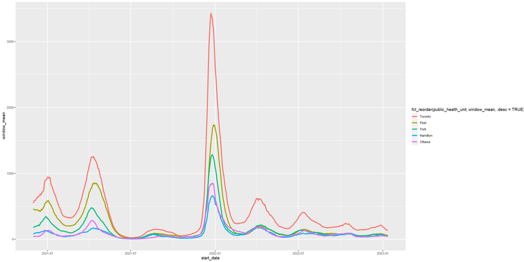

```r
# This is going to be a simpler graph so adjust our plot window size accordingly
options(repr.plot.width=20, repr.plot.height=10)

covid_phu_window.df %>%
# Filter for the top 5 infected PHUs
filter(public_health_unit %in% phu_by_total_cases_desc[1:5],
       start_date >= as.Date("2020-12-01")) %>%

# redirect the filtered result to ggplot
# 1. Data
ggplot(.) +
    # 2. Aesthetics
    aes(x = start_date, y = window_mean,                                      # Set our x and y axes
        colour = fct_reorder(public_health_unit, window_mean, .desc=TRUE)) +  # Reorder our PHUs

    # 4. Geoms
    geom_line(linewidth=1)
```

From our above plot, we can immediately see that we have issues that need remedying:

1. The overall font size of the plot is small (and I have old eyes).
2. The legend title is quite large and based specifically on the `aes()` assignment used.
3. Our axes names need to be updated and we could use a title too. We'll fix this problem later!

## 1.1.0 Control the display of all non-data elements with `theme()`

Although we haven't directly discussed themes yet, we have seen it appearing here and there in our individual plots. The influence of themes sets and controls the *presentation* of titles, labels, text, background, legends, etc. You don't directly change the actual information presented in these elements.

Calls to `theme()` generally take the form of `theme(element.component.sub-component = element_*(parameter = value))`

Some basic elements include line, rect, text, title, and aspect.ratio. Altering these elements in `theme()` will alter all elements of their kind (ie all lines, rectangles, text etc.). Alternatively specific element components can be altered more directly. The following table lists most of the possible theme elements and components. They can be as specific as `axis.title.x.top`. More detailed descriptions can be found [here](https://ggplot2.tidyverse.org/reference/theme.html).

| Element | Description | Components | Sub-components | Other |
| --- | --- | --- | --- | --- |
| axis | x and y axis elements | title, text, ticks, line | x, y, length | top, bottom, left, right |
| legend | all legend elements | background, margin, spacing, key, text, title, position, direction, justification, box | x, y, size, height, width, align, just, spacing |  |
| panel | background plotting area | background, border, spacing, grid | x, y, major, minor |  |
| plot | entire plot | background, title, subtitle, caption, tax, margin | position |  |
| strip | facet labels | background, placement, text, switch | x, y, text, pad | grid, wrap |

You update or set your individual elements using the `element_*()` functions. Within each element you can typically control aesthetics like fill, colour/color, size, etc. Below is a summary of the elements of concern and their parameters. Specific `elements_*()` will correspond with the above `theme` elements.

| element call | description | fill | colour | size | linetype | lineend | arrow | family | face | hjust | vjust | angle | lineheight | margin |
| --- | --- | --- | --- | --- | --- | --- | --- | --- | --- | --- | --- | --- | --- | --- |
| element_line() | formatting of lines |  | $\checkmark$ | $\checkmark$ | $\checkmark$ | $\checkmark$ | $\checkmark$ |  |  |  |  |  |  |  |
| element_text() | formatting of text |  | $\checkmark$ | $\checkmark$ |  |  |  | $\checkmark$ | $\checkmark$ | $\checkmark$ | $\checkmark$ | $\checkmark$ | $\checkmark$ | $\checkmark$ |
| element_rect() | borders and background | $\checkmark$ | $\checkmark$ | $\checkmark$ | $\checkmark$ |  |  |  |  |  |  |  |  |  |
| element_blank() | draws nothing, and assigns no space |  |  |  |  |  |  |  |  |  |  |  |  |  |

`inherit.blank` is an additional parameter you can use in these functions that is normally set to `FALSE`. When set to `TRUE`, if a parental layer uses `element_blank()`, it will cause this element to be blank as well. For example `axis.title` is the parent of `axis.title.x`. By setting the `inherit.blank = TRUE` parameter, you can override/nullify aesthetics assignment layers as long as a parent layers has set those elements to `element.blank()`. It's a good way to remove additional layer effects if needed!

### 1.1.1 Move your legend(s) using the `legend.position` option

Let's start with one of the most oft-intrusive components of our visualizations. While necessary, the legends often default to the right-hands side of our visualizations where they can take up extra horizontal space without requiring much vertical space!

### 1.1.1.1 Moving your legend within the plot area

When we are looking to move our legends to different positions, there are 2 areas to consider. The first is the plot area itself which *surrounds* the data panel (where our data is plotted). The `legend.position` parameter can take in two types of values. The first is a set of characters: `top`, `bottom`, `left`, and `right` which relates to the plot area.

Let's start with altering our legend position within the plot area. It's taking up quite a bit of space on the side. We'll worry about the label issues later. For now, let's move the legend to the bottom of the plot. At the same time, let's increase our overall text size for the plot.

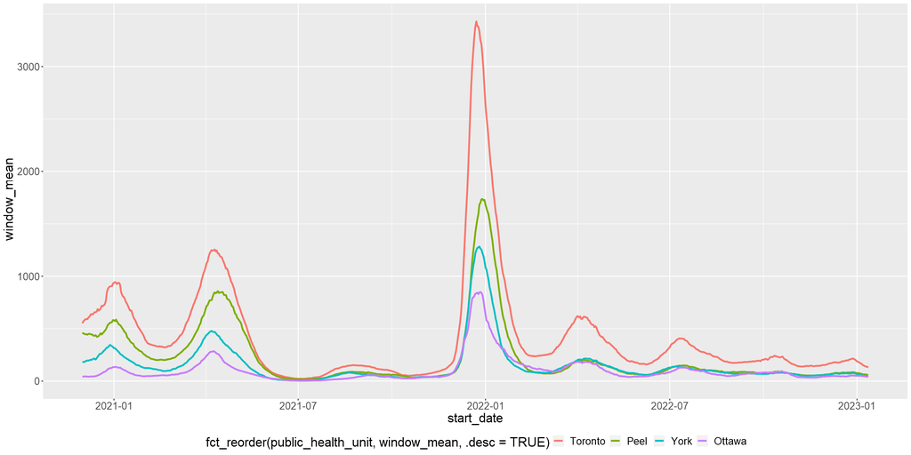

```r
# This is going to be a simpler graph so adjust our plot window size accordingly
options(repr.plot.width=20, repr.plot.height=10)

# Build our plot and data from scratch
covid_phu_window.df %>%
# Filter for the top 4 infected PHUs
filter(public_health_unit %in% phu_by_total_cases_desc[1:4],
       start_date >= as.Date("2020-12-01")) %>%

# redirect the filtered result to ggplot
# 1. Data
ggplot(.) +
    # 2. Aesthetics
    aes(x = start_date, y = window_mean,                                      # Set our x and y axes
        colour = fct_reorder(public_health_unit, window_mean, .desc=TRUE)) +  # Reorder our PHUs

    # Theme elements
    theme(text = element_text(size=20), # set text size to 20
          ### 1.1.1 Move the legend to the bottom
          legend.position = "bottom"
         ) +

    # 4. Geoms
    geom_line(linewidth=1)
```

### 1.1.1.2 Move a legend to within your data panel

Instead of moving the legend to the bottom of our plot area, let's use the empty space in the top left corner of the data panel instead by accessing the coordinate system ([0:1], [0:1]) that represents the relative positioning of elements within the panel. This system, follows a `c(x, y)` setup that matches the data panel with (0,0) representing the lower left corner.

Before we move the legend onto our panel, however, we also have to remember *where* the legend itself is anchoring when we move it. Are we asking to put the bottom-right corner of the legend into the top-left corner of the plot? Or do we want to match the legend anchor so that the top-left corners are aligned?

Use the `legend.justification` parameter to properly set this property when moving your legend. It uses the same two-point coordinate concept that we'll use for `legend.position`.

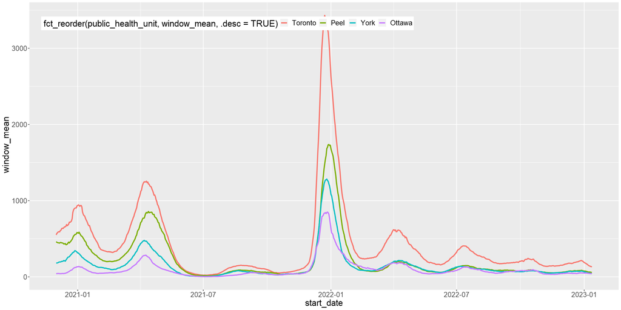

```r
# This is going to be a simpler graph so adjust our plot window size accordingly
options(repr.plot.width=20, repr.plot.height=10)

# Build our plot and data from scratch
covid_phu_window.df %>%
# Filter for the top 4 infected PHUs
filter(public_health_unit %in% phu_by_total_cases_desc[1:4],
       start_date >= as.Date("2020-12-01")) %>%

# redirect the filtered result to ggplot
# 1. Data
ggplot(.) +
    # 2. Aesthetics
    aes(x = start_date, y = window_mean,                                      # Set our x and y axes
        colour = fct_reorder(public_health_unit, window_mean, .desc=TRUE)) +  # Reorder our PHUs

    # Theme elements
    theme(text = element_text(size=20), # set text size to 20
          ### 1.1.1.2 Move the legend around to within the panel space
          legend.justification = c(0,1),
          legend.position = c(0.02, 0.95),
          legend.direction = "horizontal"
         ) +

    # 4. Geoms
    geom_line(linewidth=1)
```

## 1.1.2 Update the background panel and lines

There are a few more things we can do to the plot for now that include updating the background panel to get rid of the grey colour and maybe darkening our axis tick lines and axis lines themselves.

1. We'll use the `panel.background` parameter which expects an `element_rect()` to define it's properties.
2. `panel.grid.*` gives us access to the background axes lines using `element_line()`
3. We'll work with `axis.*` elements to to update their format a bit too.
4. Let's spice up the `plot` a little bit by setting the overall background colour.

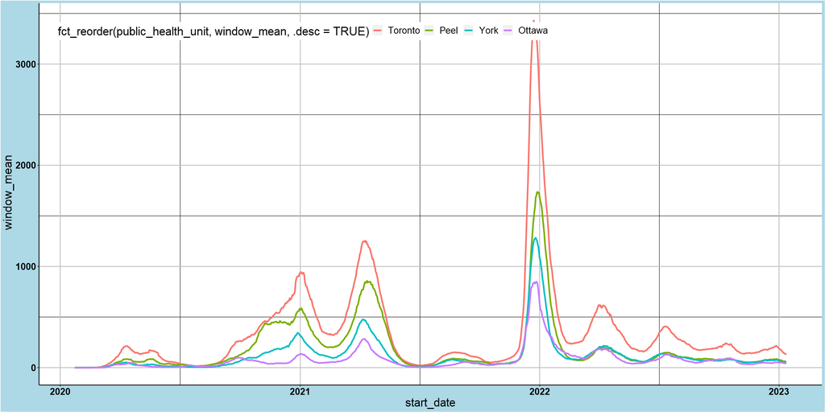

```r
# This is going to be a simpler graph so adjust our plot window size accordingly
options(repr.plot.width=20, repr.plot.height=10)

# Build our plot and data from scratch
covid_phu_window.df %>%
# Filter for the top 5 infected PHUs
filter(public_health_unit %in% phu_by_total_cases_desc[1:4]) %>%

# redirect the filtered result to ggplot
# 1. Data
ggplot(.) +
    # 2. Aesthetics
    aes(x = start_date, y = window_mean,                                      # Set our x and y axes
        colour = fct_reorder(public_health_unit, window_mean, .desc=TRUE)) +  # Reorder our PHUs

    # Theme elements
    theme(text = element_text(size=20), # set text size to 20

          # Move the legend around to within the panel space
          legend.justification = c(0,1),
          legend.position = c(0.02,0.95),
          legend.direction = "horizontal",

          ### 1.1.2 Update the panel colour and line colours
          panel.background = element_rect("white"),
          panel.grid.major = element_line("grey"),
          panel.grid.minor = element_line("black"),

          ### 1.1.2 Use a black line for the axes
          axis.line = element_line("black"),
          axis.text = element_text(colour = "black", face="bold"),

          ### 1.1.2 Update the plot background colour
          plot.background = element_rect("lightblue")
         ) +

    # 4. Geoms
    geom_line(linewidth=1)
```

**One vs. multiple theme() layers:** You'll notice from our code above, that we only make a *single* call to the **theme()** layer. Each line, however, represents a different element of the theme that we are altering. In general, while the order of these items does matter, if it makes sense for you, you can add multiple layers for **theme()** grouping them by the specific element types you want to work with like axes, background, and titles.

## 1.2.0 Use premade themes from `ggplot2`

In our above example we made alterations to the theme that affected background colour and axis lines. While some of you may lean on the more artistic side you can also use premade themes from both the `ggplot2` package and additional packages like `ggthemes`. Below you'll find a list of the themes from `ggplot2`.

| Theme | Description |
| --- | --- |
| theme_gray() | Grey background colour, white grid lines. |
| theme_bw() | White background colour, grey grid lines. |
| theme_linedraw() | White background colour, black lines of various widths |
| theme_light() | White background colour, grey lines of various widths |
| theme_dark() | Dark background colour, grey lines of various widths |
| theme_minimal() | No background annotations, grey lines |
| theme_classic() | White background, x/y axis lines, no grid lines |
| theme_void() | A copmletely empty themes, white background, no axis or grid lines |

If you find a theme that you *mostly* like, you can use that as a base to your graph *before* making additional `theme()` alterations. Let's try a few of these out.

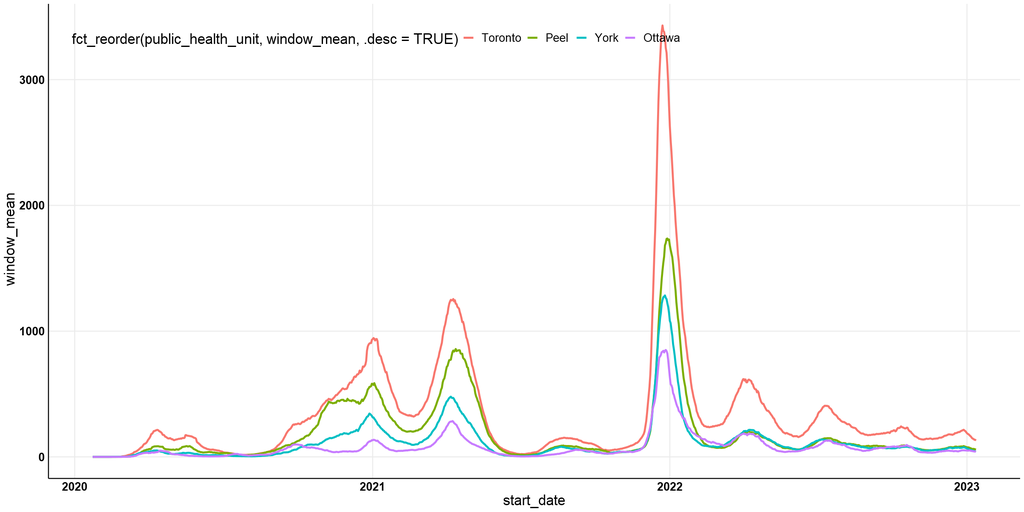

```r
# This is going to be a simpler graph so adjust our plot window size accordingly
options(repr.plot.width=20, repr.plot.height=10)

# Build our plot and save to an object
phu_window.plot <- covid_phu_window.df %>%
# Filter for the top 5 infected PHUs
filter(public_health_unit %in% phu_by_total_cases_desc[1:4]) %>%

# redirect the filtered result to ggplot
# 1. Data
ggplot(.) +
    # 2. Aesthetics
    aes(x = start_date, y = window_mean,                                      # Set our x and y axes
        colour = fct_reorder(public_health_unit, window_mean, .desc=TRUE)) +  # Reorder our PHUs

    # Theme elements
    ### 1.2.0 Start with a base theme
    theme_minimal() +

    theme(text = element_text(size=20), # set text size to 20

          # Move the legend around to within the panel space
          legend.justification = c(0,1),
          legend.position = c(0.02,0.95),
          legend.direction = "horizontal",

          # Update the panel to drop the minor y-axis grid lines
          panel.grid.minor = element_blank(),

          # Use a black line for the axes
          axis.line = element_line(colour="black"),
          axis.text = element_text(colour="black", face="bold"),
         ) +

    # 4. Geoms
    geom_line(size=1)

# plot our object to standard output
phu_window.plot
```

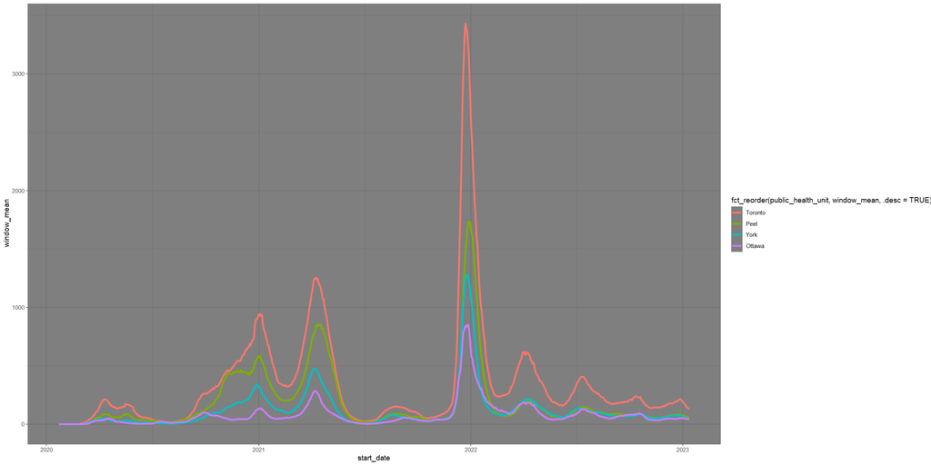

```r
# Try to add theme_dark() to our plot. What are the consequences?
phu_window.plot + theme_dark()
```

**Layer order matters!** It cannot be stressed enough that layer order matters. We've mentioned it in previous sections as we work through these figures but the above code is our clearest example. Even though we had set the font formats, and legend positions, all of that was erased with a single added **theme_dark()** layer. This is because the *most recent layer* overrides all of the aesthetics from previous ones. Sometimes this has only a small effect depending on the inheritance structure or it can essentially reset everything! *Caveat emptor!*

## 1.3.0 `ggthemes` mimics visual styles from multiple sources

If you are feeling a little more daring with your choices, you can turn to the `ggthemes` packages to mimic styles from a number of publications such as the Economist, and Wall Street Journal. You can look up a list of the various themes at https://github.com/jrnold/ggthemes.

Like the themes provided by ggplot, you can also make edits to these themes within your scripts.

Two additional package options with different colour palettes and shapes are `ggthemr` and `ggsci`.

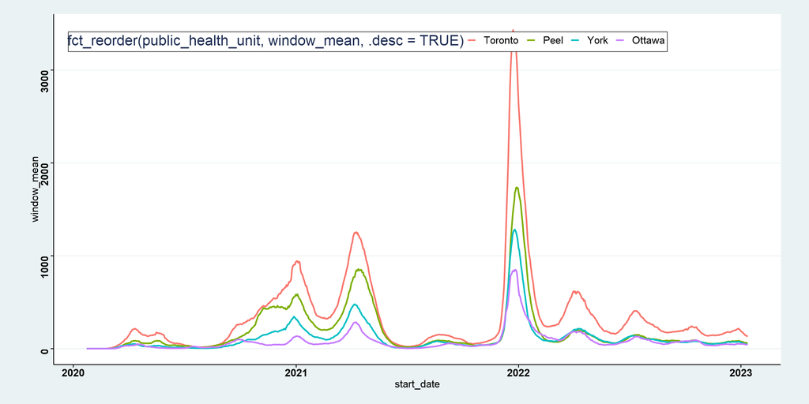

```r
# This is going to be a simpler graph so adjust our plot window size accordingly
options(repr.plot.width=20, repr.plot.height=10)

# Build our plot
covid_phu_window.df %>%
# Filter for the top 5 infected PHUs
filter(public_health_unit %in% phu_by_total_cases_desc[1:4]) %>%

# redirect the filtered result to ggplot
# 1. Data
ggplot(.) +
    # 2. Aesthetics
    aes(x = start_date, y = window_mean,                                      # Set our x and y axes
        colour = fct_reorder(public_health_unit, window_mean, .desc=TRUE)) +  # Reorder our PHUs

    # Theme elements
    ### 1.3.0 Switch to the stata theme
    theme_stata() +

    theme(text = element_text(size=20), # set text size to 20
          # Move the legend around to within the panel space
          legend.justification = c(0,1),
          legend.position = c(0.02,0.95),
          legend.direction = "horizontal",

          # Use a black line for the axes
          axis.line = element_line(colour = "black"),
          axis.text = element_text(colour = "black", face="bold"),
         ) +

    # 4. Geoms
    geom_line(size=1)
```

# 2.0.0 Text content can be updated through a number of layers

Now that we have played around with how to reposition legends, and other elements of your plot, we can discuss how to change the actual text content of your plot. Many times we want to relabel axes or legends, even legend labels. There are a number of layers we can work through but we'll present some of the simplest ways to accomplish this.

## 2.1.0 Label titles and axes individually or with the `labs()` command

Up to this point, we've seen the use of different commands to alter the labels and titles like:

- `xlab()`: Update the x-axis label.
- `ylab()`: Update the y-axis label.
- `ggtitle()`: Update the plot title.

You can also access multiple options within a single call to the `labs()` layer which accepts the following parameters:

- `...`: a list of name-value pairs that map back to an aesthetic (ie `x = "X-axis"` or `colour = "Population"`)
  - Use the `NULL` value to remove a title for a specific label.
- `title`, `subtitle`: the title with a subtitle displayed below
- `caption`: the text for the caption is displayed in the bottom-right by default
- `tag`: figure text tag/label usually for figure panels in manuscripts

Let's relabel our plot axis and titles to be more accurate. For now we'll drop the **Stata** theme and go with our own alteration of `theme_minimal()`. We'll also include a caption in the bottom right to explain how we display the 14-day rolling mean. You'll also notice that the extremely long legend title will be quite easily fixed!

**Note**: a quick way of adding space to your titles, is to include the `\n` character which inserts a carriage return.

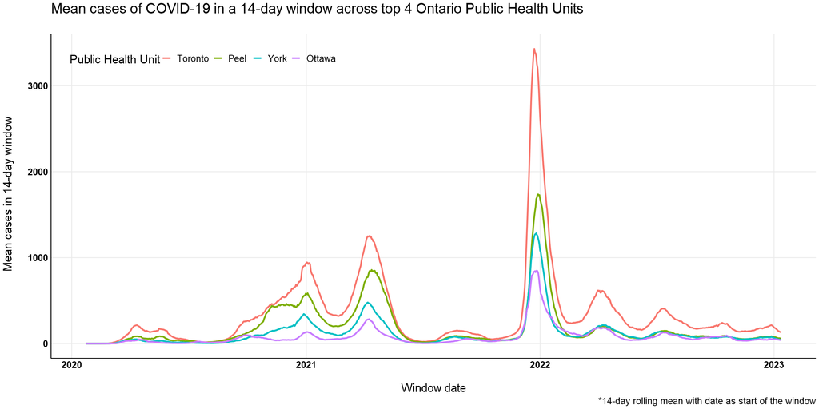

```r
# This is going to be a simpler graph so adjust our plot window size accordingly
options(repr.plot.width=20, repr.plot.height=10)

# Build our plot
covid_phu_window.df %>%
# Filter for the top 5 infected PHUs
filter(public_health_unit %in% phu_by_total_cases_desc[1:4]) %>%

# redirect the filtered result to ggplot
# 1. Data
ggplot(.) +
    # 2. Aesthetics
    aes(x = start_date, y = window_mean,                                      # Set our x and y axes
        colour = fct_reorder(public_health_unit, window_mean, .desc=TRUE)) +  # Reorder our PHUs

    # Theme elements
    # Start with a base theme
    theme_minimal() +

    theme(text = element_text(size=20), # set text size to 20

          # Move the legend around to within the panel space
          legend.justification = c(0,1),
          legend.position = c(0.02,0.95),
          legend.direction = "horizontal",

          # Update the panel to drop the minor axis grid lines
          panel.grid.minor = element_blank(),

          # Use a black line for the axes
          axis.line = element_line(colour = "black"),
          axis.text = element_text(colour = "black", face="bold"),
         ) +

    ### 2.1.0 Add labels to our plot
    labs(title = "Mean cases of COVID-19 in a 14-day window across top 4 Ontario Public Health Units\n",
         x = "\nWindow date",
         y = "Mean cases in 14-day window\n",
         colour = "Public Health Unit",
         caption = "*14-day rolling mean with date as start of the window") +

    # 4. Geoms
    geom_line(linewidth=1)
```

## 2.2.0 Relabel axis ticks, and legend labels with the `labels` parameter

In last lecture's assignment, you likely would have used the `xlim()` or `ylim()` layers to set the axis limits on some of your visualizations. As with all things, there is more than one pathway to our goals.

The `scale_*()` functions can also be used to set the title, limits, breaks, and labels along your axes. Some of these parameters are redundant and can override other `ggplot2` layer commands, depending on the order you have included them.

| Parameter | Equivalent ggplot layer command |
| --- | --- |
| name | xlab(), ylab(), lab(x), lab(y) |
| limits | xlim(), ylim() |
| break | Determine when axis tick marks are generated |
| labels | *Rename* the labels present at axis tick marks |

### 2.2.1 Relabel date axes and legend labels with `scale_*_date()`

We'll start with a familiar idea we've been working with since lecture 1. A good portion of our pandemic visualizations have focused on looking at data over time. With the `scale_x_date()` layer, we have set limits, breaks and label formats. Unlike more discrete data sets that we'll see later, the `scale_*_date()` layer has some very specific parameters that surround the idea of dates and how they are formatted. Last week we took a close look at `scale_x_date()` in section **3.3.2** of the lecture:

- `breaks`: while you can set specific breaks for dates with this parameter you will need a specific vector of `date` values that matches your own data groups.
- `date_breaks`: a convenient string representation to describe the *distance* between breaks like `"12 days"`, or `"3 years"`. This parameter will override any information passed to `breaks`.
- `date_labels`: a convenient string representation to describe the *format* of dates defined by `strftime()`. Information found [here](https://rdrr.io/r/base/strptime.html)

Let's start by relabeling our x-axis to show us our dates by month and at the same time we set a limit to show us data starting in December of 2020. We've done this before so it should be easy.

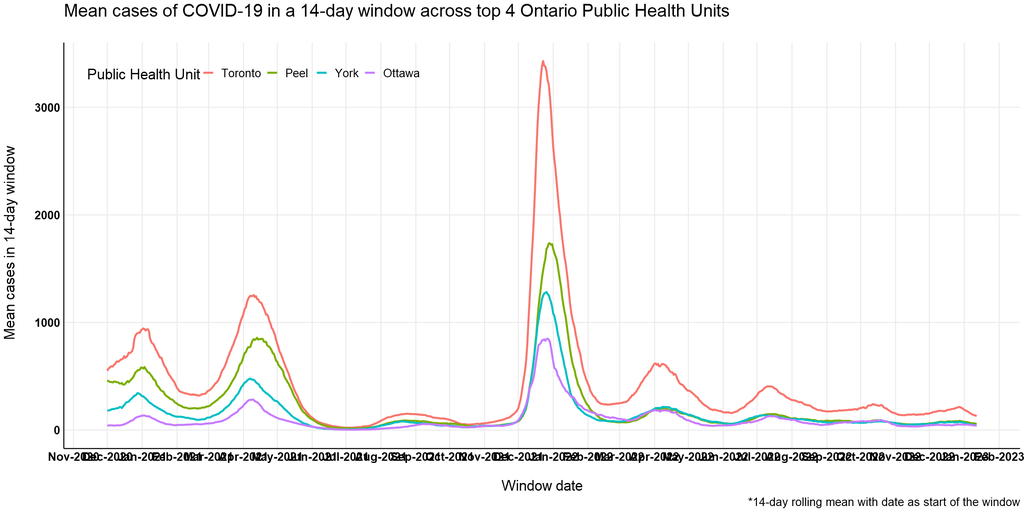

```r
# This is going to be a simpler graph so adjust our plot window size accordingly
options(repr.plot.width=20, repr.plot.height=10)

# Build our plot
covid_phu_window.df %>%
# Filter for the top 5 infected PHUs
filter(public_health_unit %in% phu_by_total_cases_desc[1:4]) %>%

# redirect the filtered result to ggplot
# 1. Data
ggplot(.) +
    # 2. Aesthetics
    aes(x = start_date, y = window_mean,                                      # Set our x and y axes
        colour = fct_reorder(public_health_unit, window_mean, .desc=TRUE)) +  # Reorder our PHUs

    # Theme elements
    # Start with a base theme
    theme_minimal() +

    theme(text = element_text(size=20), # set text size to 20

          # Move the legend around to within the panel space
          legend.justification = c(0,1),
          legend.position = c(0.02,0.95),
          legend.direction = "horizontal",

          # Update the panel to drop the minor axis grid lines
          panel.grid.minor = element_blank(),

          # Use a black line for the axes
          axis.line = element_line(colour = "black"),
          axis.text = element_text(colour = "black", face="bold"),
         ) +

    # Add labels to our plot
    labs(title = "Mean cases of COVID-19 in a 14-day window across top 4 Ontario Public Health Units\n",
         x = "\nWindow date",
         y = "Mean cases in 14-day window\n",
         colour = "Public Health Unit",
         caption = "*14-day rolling mean with date as start of the window") +

    # 3. Scaling
    ### 2.2.1 Start looking at data from December 2020 onwards
    scale_x_date(limits = c(as.Date("2020-12-01"),                         # Set a start date for our limit
                            as.Date(max(covid_phu_window.df$start_date))), # Identify the last date and use that
                 date_breaks = "1 month",                                  # How will we break up the dates?
                 date_labels = "%b-%Y") +                                  # How will we format labels

    # 4. Geoms
    geom_line(linewidth=1)
```

### 2.2.1.1 Adjust your axis text with the `element_text()` function

At this point you'll notice that our x-axis text is also pretty unclean. Let's revisit the `axis.text.x` component of theme to deal with this. There are a few things we can influence with this `element_text()` including:

- `angle`: use this to rotate text from a horizontal position, in a counter-clock-wise direction.
- `vjust` and `hjust`: the **v**ertical and **h**orizontal justification of your text as a value from 0 to 1, where 0.5 is "centered".
- `family`: determine the font used
- `face`: determine the font face (plain, bold, italic, bold.italic)
- `size`, `lineheight`, `color`, `colour`: alter other characteristics of your text display
- `debug`: a handy tool that draws the a border around your complete text area and a point where each label is anchored. Great for helping to get that "perfect" look on your figures.

Let's fix up our current visualization by rotating our text and right-justifying it.

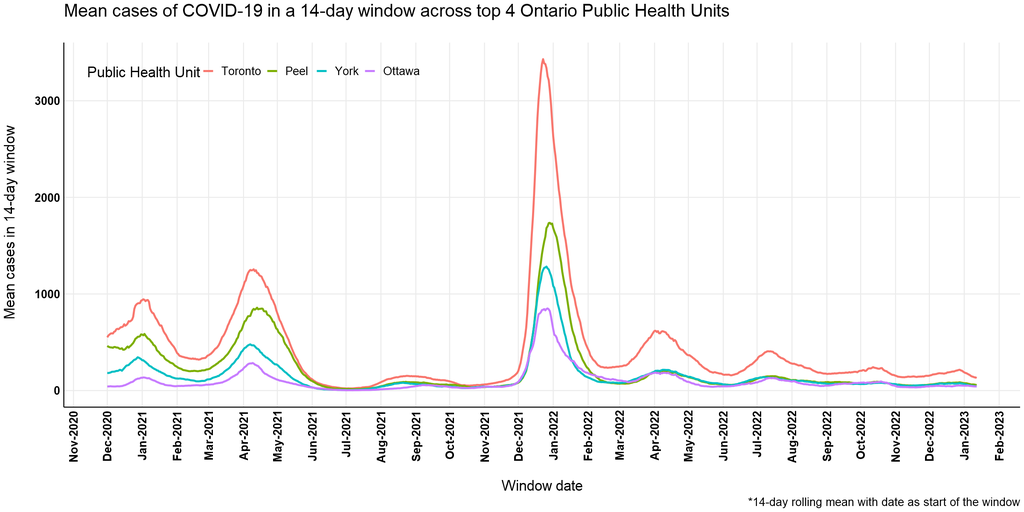

```r
# This is going to be a simpler graph so adjust our plot window size accordingly
options(repr.plot.width=20, repr.plot.height=10)

# Build our plot
covid_phu_window.df %>%
# Filter for the top 5 infected PHUs
filter(public_health_unit %in% phu_by_total_cases_desc[1:4]) %>%

# redirect the filtered result to ggplot
# 1. Data
ggplot(.) +
    # 2. Aesthetics
    aes(x = start_date, y = window_mean,                                      # Set our x and y axes
        colour = fct_reorder(public_health_unit, window_mean, .desc=TRUE)) +  # Reorder our PHUs

    # Theme elements
    # Start with a base theme
    theme_minimal() +

    theme(text = element_text(size=20), # set text size to 20

          # Move the legend around to within the panel space
          legend.justification = c(0,1),
          legend.position = c(0.02,0.95),
          legend.direction = "horizontal",

          # Update the panel to drop the minor axis grid lines
          panel.grid.minor = element_blank(),

          # Use a black line for the axes
          axis.line = element_line(colour = "black"),
          axis.text = element_text(colour = "black", face="bold"),

          ### 2.2.1.1 Adjust the x-axis text
          axis.text.x = element_text(angle = 90,  # Rotate 90
                                     hjust = 1,   # Right-justify
                                     vjust = 0.5) # Centre text "vertically" on axis tick
         ) +

    # Add labels to our plot
    labs(title = "Mean cases of COVID-19 in a 14-day window across top 4 Ontario Public Health Units\n",
         x = "\nWindow date",
         y = "Mean cases in 14-day window\n",
         colour = "Public Health Unit",
         caption = "*14-day rolling mean with date as start of the window") +

    # 3. Scaling
    # Start looking at data from December 2020 onwards
    scale_x_date(limits = c(as.Date("2020-12-01"),                         # Set a start date for our limit
                            as.Date(max(covid_phu_window.df$start_date))), # Identify the last date and use that
                 date_breaks = "1 month",                                  # How will we break up the dates?
                 date_labels = "%b-%Y") +                                  # How will we format labels

    # 4. Geoms
    geom_line(linewidth=1)
```

### 2.2.2 Relabel continuous axis ticks by altering `limits` and `breaks`

Much of your quantitative data will usually come as a continuous series of values. We've played around with these scales before using `scale_*_log10` in lecture and assignment. Similarly, we can alter continuous axes without necessarily transforming them. This is accomplished via the `scale_*_continuous()` layer. With these types of layers, we have access to parameters like:

- `breaks`, `minor_breaks`: a numeric vector of positions OR a function that takes the limits as input and returns breaks as output for the parameter specified.
- `n.breaks`: an integer to suggest the number of major breaks. The plotting algorithm may alter this value to ensure nice break labels. This will only work if `breaks = waiver()` (the default for `breaks`).
- `labels`: a character vector matching labels to the major breaks.
- `limits`: a numeric vector `c(lower, upper)`

Let's break our y-axis into major tick-marks of every 500 cases by altering `scale_y_continuous()` with the `seq()` function. At the same time, let's remove the title from our legend by setting the guide in `labs()` to a `NULL` value.

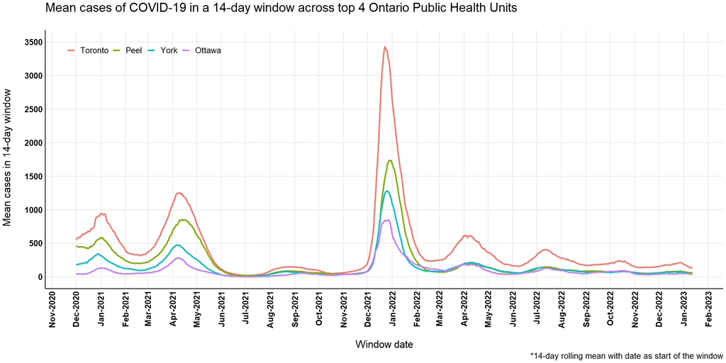

```r
# This is going to be a simpler graph so adjust our plot window size accordingly
options(repr.plot.width=20, repr.plot.height=10)

# Build our plot and save to an object for later use
phu_window.plot <- covid_phu_window.df %>%
# Reorder the PHU factor here
mutate(public_health_unit = fct_reorder(public_health_unit, window_mean, .desc=TRUE)) %>%
# Filter for the top 5 infected PHUs
filter(public_health_unit %in% phu_by_total_cases_desc[1:4]) %>%

# redirect the filtered result to ggplot
# 1. Data
ggplot(.) +
    # 2. Aesthetics
    aes(x = start_date, y = window_mean,                                      # Set our x and y axes
        colour = public_health_unit) +

    # Start with a base theme
    theme_minimal() +

    theme(text = element_text(size=20), # set text size to 20

          # Move the legend around to within the panel space
          legend.justification = c(0,1),
          legend.position = c(0.02,0.95),
          legend.direction = "horizontal",

          # Update the panel to drop the minor axis grid lines
          panel.grid.minor = element_blank(),

          # Use a black line for the axes
          axis.line = element_line(colour = "black"),
          axis.text = element_text(colour = "black", face="bold"),

          # Adjust the x-axis text
          axis.text.x = element_text(angle = 90,  # Rotate 90
                                     hjust = 1,   # Right-justify
                                     vjust = 0.5) # Centre text "vertically" on axis tick
         ) +

    # Add labels to our plot
    labs(title = "Mean cases of COVID-19 in a 14-day window across top 4 Ontario Public Health Units\n",
         x = "\nWindow date",
         y = "Mean cases in 14-day window\n",
         colour = NULL,
         caption = "*14-day rolling mean with date as start of the window") +

    # 3. Scaling
    # Start looking at data from July 2020 onwards
    scale_x_date(limits = c(as.Date("2020-12-01"),                         # Set a start date for our limit
                            as.Date(max(covid_phu_window.df$start_date))), # Identify the last date and use that
                 date_breaks = "1 month",                                  # How will we break up the dates?
                 date_labels = "%b-%Y") +                                  # How will we format labels

    ### 2.2.2 Change our y-axis breaks
    scale_y_continuous(limits = c(0, 3500), breaks = seq(0, 3500, 500)) +

    # 4. Geoms
    geom_line(linewidth=1)

# plot our object to standard output
phu_window.plot
```

### 2.2.3 Relabel discrete axes and legend labels in `scale_*_discrete()`

For various reasons, you may have categorical or grouped data with unusual names. It may be convenient to code your data this way but letting `ggplot2` assign these to your axes or labels may not be suitable. Instead, you can manually rename them using the `labels` parameter with your various `scale_*_discrete()` layers.

When manually labeling your categories be sure to supply a vector with the correct number of arguments to match the number of levels in your categories or groups.

Let's revisit some of our age-grouped data from last week which was visualized as *grouped violin plot with inset boxplots*. Recall that our data was labelled by the variable `age_group` using "0 to 4", "5 to 11", etc. We'll modify those in the plot (rather than the data frame) to a format that looks like "0-4", "5-11", etc.

```r
# Let's briefly review the dataset
str(covid_demographics_total.df, give.attr = FALSE)
```

```
gropd_df [476 x 15] (S3: grouped_df/tbl_df/tbl/data.frame)
 $ period                      : chr [1:476] "recent" "recent" "recent" "recent" ...
 $ from_date                   : chr [1:476] "18-Feb-23" "18-Feb-23" "18-Feb-23" "18-Feb-23" ...
 $ to_date                     : chr [1:476] "04-Mar-23" "04-Mar-23" "04-Mar-23" "04-Mar-23" ...
 $ public_health_unit          : chr [1:476] "Algoma" "Algoma" "Algoma" "Algoma" ...
 $ age_group                   : Factor w/ 7 levels "0 to 4","5 to 11",..: 1 3 4 5 2 6 7 1 3 4 ...
 $ total_cases                 : num [1:476] 4 2 15 24 1 19 8 2 1 4 ...
 $ total_rate                  : num [1:476] 83.6 22.2 57.6 84.4 12.5 ...
 $ total_hospitalizations_count: num [1:476] 0 0 0 2 0 8 2 0 0 0 ...
 $ total_hospitalizations_rate : num [1:476] 0 0 0 7 0 24.3 25.1 0 0 0 ...
 $ male_cases                  : num [1:476] 2 0 4 9 0 11 4 1 0 0 ...
 $ female_cases                : num [1:476] 2 2 11 15 1 8 4 1 1 4 ...
 $ percent_cases               : num [1:476] 0.0548 0.0274 0.2055 0.3288 0.0137 ...
 $ percent_hospitalizations    : num [1:476] 0 0 0 0.167 0 ...
 $ percent_male_cases          : num [1:476] 0.5 0 0.267 0.375 0 ...
 $ percent_female_cases        : num [1:476] 0.5 1 0.733 0.625 1 ...
```

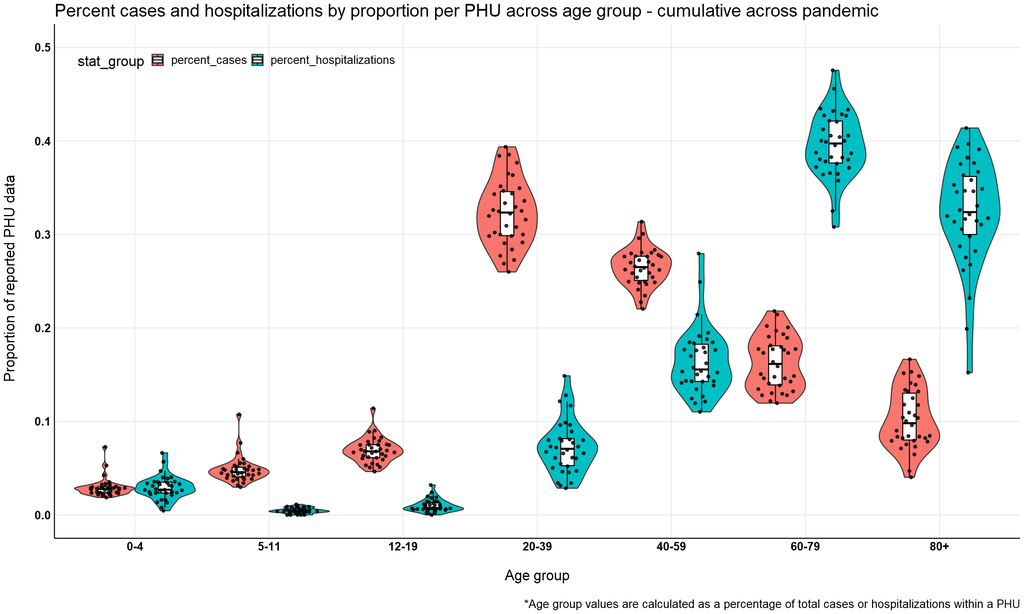

```r
# Adjust our plot window size according to the expected output
options(repr.plot.width=20, repr.plot.height=12)

# Build and save the plot for later use
demographics.plot <- covid_demographics_total.df %>%
# Ungroup this dataframe to clean it up a little
ungroup() %>%
# Filter for cumulative data
filter(period == "cumulative") %>%
# Select for just the important columns
select(public_health_unit, age_group, percent_cases, percent_hospitalizations) %>%
# Pivot the modified table to capture the "stat_group" of percent_cases vs percent_hospitalizations
pivot_longer(cols=c(3,4), names_to = "stat_group", values_to = "percent_PHU_total") %>%

# Plot the data as a grouped violin plot with inset boxplot

# 1. Data
ggplot(.) +
    # 2. Aesthetics
    aes(x=age_group, y = percent_PHU_total) +

    # Start with a base theme
    theme_minimal() +

    theme(text = element_text(size=20), # set text size to 20

          # Move the legend around to within the panel space
          legend.justification = c(0,1),
          legend.position = c(0.02,0.95),
          legend.direction = "horizontal",

          # Update the panel to drop the minor axis grid lines
          panel.grid.minor = element_blank(),

          # Use a black line for the axes
          axis.line = element_line(colour = "black"),
          axis.text = element_text(colour = "black", face="bold"),
         ) +

    # Add labels to the plot
    labs(title = "Percent cases and hospitalizations by proportion per PHU across age group - cumulative across pandemic",
         x = "\nAge group",
         y = "Proportion of reported PHU data\n",
         caption = "\n*Age group values are calculated as a percentage of total cases or hospitalizations within a PHU") +

    # 3. Scaling
    scale_y_continuous(limits = c(0, 0.5)) +         # Set the limits of our y-axis
    scale_colour_manual(values=c("black", "black"))+ # we'll need this to fix our boxplot outlines

    ### 2.2.3 Set the labels of our x-axis categories
    scale_x_discrete(labels=c("0-4", "5-11", "12-19", "20-39", "40-59", "60-79", "80+"))+

    # 4. Data
    # multi-factor violin plots but keep the width consistent
    geom_violin(scale="width", aes(fill=stat_group)) +

    # Boxplot but smaller width so they reside "within" the violin plot
    geom_boxplot(aes(colour = stat_group), width=0.2,
                 position = position_dodge(width=0.9),
                 outlier.shape=NA) + # Remove the outliers

    # Add in all of the data points
    geom_quasirandom(dodge.width = 0.85, aes(group=stat_group), alpha = 0.8)

# Show the plot
demographics.plot
```

## 2.3.0 Alter your legends with the `guide` parameter or `guides()` layer

Nearly there with updating this plot! We've relabeled the the x-axis categories but our legend title isn't quite there. Previously we used the `labs()` layer to handle this aspect but this time around we really want to also alter the labels of our data categories to "% cases" and "% hospitalizations". Before we get into that, let's talk a little more about legends.

Normally you can let `ggplot2` take the wheel and automatically generate guides for you. Whenever you set colour/fill/linetype etc in your aesthetics, this will generate a legend. When the groups are mapped in the same way (i.e. the same labels!) between different aesthetics, the legends may be combined.

There will be instances, however, when you need to adjust your legend or get rid of it all together. This could range from titles, to combining your guides across different aesthetics commands. There are a number of ways to achieve the same result when working with guides and we'll go through a number of examples. First, however, we should discuss the *types* of legends:

| guide | short call | Description |
| --- | --- | --- |
| guide_legend() | legend | The base prototype of the legend which integrates how geoms are mapped into values. |
| guide_bins() | bins | A binned version of legends which places ticks between keys and has its own small axis |
| guide_colourbar() | colourbar | For mapping continous colour/fill scales from using `scale_fill_*()` and `scale_colour_*()`. |
| guide_coloursteps() | coloursteps | A version of guide_colourbar() except for binned colour and fill scales rather than gradients. |
| none | NA | Suppress the legend as specified |

We briefly saw the use of a colourbar in our last lecture when using a continuous variable to set the colour of our barplots. Each type has it's own use depending on how you want to describe your data. Within each of the guide types, you can update parameters about text within the legend.

| Component | Sub-components |
| --- | --- |
| title | name, position, theme, hjust, vjust |
| label | name, position, theme, hjust, vjust |
| key | width, height |
| order | you can determine the order of the guide amongst others using integers [1:99]. 0 sets order by an algorithm |
| other | direction of guide, number of rows/cols |

So where can you use these methods?

### 2.3.1 Use `scale_*()` to set guide parameters

Within each `scale_*()` you declare you can set the parameter `guide` to one of the above guide types. To exclude a legend for that particular type, set the value to `none`.

Some layer options you may work with here are `scale_fill_discrete()` and `scale_shape_manual()` and `scale_colour_continuous()` - some of which we've seen in previous lectures. Notice that `fill`, `shape` and `colour` are all [aesthetic parameters](https://ggplot2.tidyverse.org/reference/aes_group_order.html) we can [change in our data mapping](https://ggplot2.tidyverse.org/articles/ggplot2-specs.html).

Let's update our fill guide to change the legend title to "Data category" and relabel our categories to "% cases" and "% hospitalizations" as previously discussed.

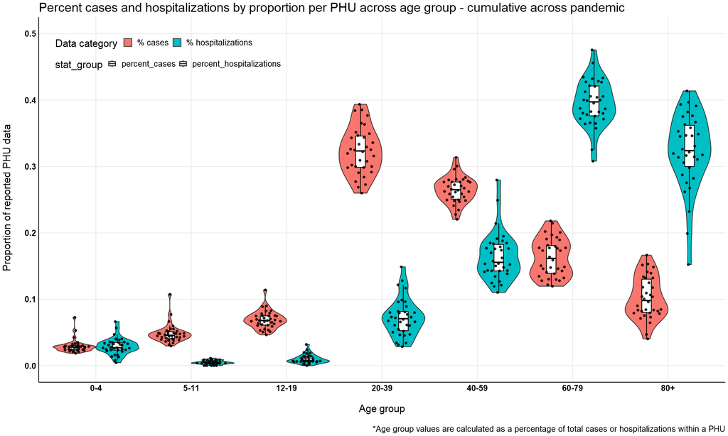

```r
# Adjust the fill scale layer for the demographics plot
demographics.plot +
    ### 2.3.1 Set the fill guide details
    scale_fill_discrete(name = "Data category",              # Guide name
                        labels = c("% cases", "% hospitalizations"))   # Relabel the categories
```

### 2.3.2 Use the `guides()` layer to manipulate multiple guides

While our output is nearly correct, there is still a problem! Now have two sets of legends! If you look carefully at the ggplot code, you'll see that we set aesthetics in three places:

- `geom_violin(scale="width", aes(fill=stat_group))`
- `geom_boxplot(aes(colour = stat_group)...`
- `geom_quasirandom(dodge.width = 0.85, aes(group=stat_group), alpha = 0.8)`

Across 3 geoms we've generated 3 aesthetic groups: `fill`, `colour` and `group`. Remember when we said that `ggplot` would take the wheel and generate legend/guide information automatically? Well this is a case where all three are mapping by the same variable so they get combined into a single legend. When we took the time to change the `fill` guide, however, it was broken away from the other two guides.

In a case like this we use the `guides()` call to set multiple guides at once using the scale types as parameters ie colour, size, shape. Much like `labs()` it gives us centralized access to guide format and settings, allowing us to quickly rectify our problem. In this case, we really don't need the `group` or `colour` aesthetics, so we'll simply get rid of them.

```r
# Adjust the fill scale layer for the demographics plot
demographics.plot +
    ### 2.3.2 Use the guides() layer and get rid of the scale_fill_discrete() layer
    guides(fill = guide_legend(title = "Data category"),
           colour = ..., group = ...) +

    # Set the fill guide details
    scale_fill_discrete(labels = c("% cases", "% hospitalizations"))   # Relabel the categories
```

**Try to minimize your layers:** In our above example we had to use **scale_fill_discrete()** and **guides()** because we needed to manipulate multiple guides but only a couple in a very simple way. This format, however, might not always be the best choice. For instance, suppose you wanted to explicitly choose your violin colours? Then a **scale_fill_manual()** layer would be required, at which point you need to decide, will you set your guide format all in this layer or work with a separate **guides()** layer? Depending on the complexity of your guides (as we'll revisit later) it may easier to keep them centralized. In other cases, you may want to set them within their own **scale_*()** layers in case you want to make changes to specific layer details more centralized. It's a balance that will be struck between your specific needs but try to be thoughtful about it to save yourself some pain in editing your code later on.

| Well you could rely on the basic colour palette but you're better off picking your own colours! |
| --- |

# 3.0.0 Colour palettes!

Up to this point, we've danced around the idea of colour in our lectures and assignments. For those of you that aren't familiar with your colour choices, here is a quick breakdown of colour palettes.

A common thing to want to do is to change colours from `ggplot2`'s default rainbow palette. There are many reasons to change a colour palette including

- making it easier on the reader's eye.
- making it colour-blind friendly.
- ensuring that plots with continuous data use good colour spectra for accurate representation.

When we talk about colour palettes and their purpose, there are 3 main types.

### 3.0.1 Use sequential colour palettes to display low to high values

*Sequential* - implies an order to your data - i.e. light to dark implies low values to high values. There are helpful when working with continuous data scales of increasing value e.g. heatmaps.

```r
# Load the RColorBrewer library
library(RColorBrewer)

# display the sequential colour palettes
display.brewer.all(type = "seq")
```

[output not shown]

### 3.0.2 Use diverging colour palettes to highlight the middle and extremes of a distribution

*Diverging* - low and high values are extremes, and the middle values are important. This palette will goes from light to dark, middle to outsides with 3 colours mainly used.

```r
# Display the diverging colour palettes
display.brewer.all(type = "div")
```

[output not shown]

### 3.0.3 Use qualitative colour palettes for categorical data

*Qualitative* - there is no quantitative relationship between colours. This is usually used for categorical data when you want each category to be visualized distinctly.

```r
display.brewer.all(type = "qual")
```

[output not shown]

## 3.1.0 Add a colour palette to a plot like a layer

Let's test one of the `RColorBrewer` palettes out on our data. We'll add it as a layer to `phu_window.plot` using `scale_colour_brewer()` to override the colour mappings defined in the `aes()` layer of the plot. Some parameters we can keep in mind:

- `type`: determines the kind of palette as sequencial (seq), diverging (div) or qualitative (qual)
- `palette`: accepts a string name for a palette or an integer that combines with `type` to pick a palette

Note that colour palettes *are not* vector recycled when plotting in `ggplot`. This means if you don't supply enough colours to match your groups, then unassigned groups will simply be cut off or not displayed.

More information on palette order and other parameters can be found [here](https://ggplot2.tidyverse.org/reference/scale_brewer.html)

```r
phu_window.plot +
    # Use the Dark2 palette
    scale_colour_brewer(palette=...)
```

```r
phu_window.plot +
    # Pick a qualitative colour palette
    scale_colour_brewer(type=..., palette=...)
```

## 3.2.0 You can always pick your own colours!

You can always choose a vector of your own colors using this 'R color cheatsheet' (https://www.nceas.ucsb.edu/~frazier/RSpatialGuides/colorPaletteCheatsheet.pdf).

Names of colours as well as hex colour codes are accepted. You can supply a manual list using the `scale_*_manual()` command.

```r
phu_window.plot +
    # Set your own manual colour choices
    scale_colour_manual(values=c(..., "cornflowerblue", "orange", ...))
```

## 3.3.0 Colour-blind friendly palettes can be found in the `viridis` package

The `viridis` package also has some nice color palettes (https://cran.r-project.org/web/packages/viridis/vignettes/intro-to-viridis.html). These colour packages are diverging palettes meant to help highlight true colour change across continuous scales. You've seen it come up a few times in our data and these palettes do well for small categorical sets but begin to blend as our number of categories increase in size.

The main calls we can use follow the format `scale_*_viridis_c/d/b()` where the "c/d/b" represents continuous/discrete/binned data and the types of additional arguments that can be passed on to augment the call. There are some additional parameters that can be used to set the colours when called:

- `option`: accepts one of 8 possible character representing 5 colour scales; "magma"/"A", "inferno"/"B", "plasma"/"C", "viridis"/"D" or "cividis"/"E".
- `direction`: sets the direction of the palette order. Use -1 to reverse it.

```r
phu_window.plot +
    # Use a colour-blind friendly palette
    scale_colour_viridis_d(...)
```

## 3.4.0 Use `after_scale` to set an aesthetic mapping dependent upon another one

There may be times when you want to link certain aesthetics to each other like `colour` and `fill` for instance. Perhaps you want to set both to a custom value but one as a lighter shade. Rather than set both mappings to a data variable *and then* using a scale layer to set the values, you can set one mapping as dependent upon another. There are transformations and mappings of data to aesthetics happening under the hood at 3 stages when evaluating a `ggplot` object.

1. The default stage takes place when you first use the aes() layer to map the data layer directly to an aesthetic.
2. The second stage occurs after data has been transformed by the stat() layer. This occurs in places where data is summarized, such as a geom_bar() as the data isn't directly being used but rather summarized into a set of data for display. You would use `after_stat()` to access this data.
3. The final stage is after the data has been transformed and mapped by the plot scales (eg `scale_colour_manual()`). From there, you can dictate how another aesthetic mapping will determine its values.

Using the `after_scale()` function will postpone an aesthetic mapping until after the data has been scaled. As we'll see next, when used properly, you will tie the aesthetics of one aspect to the aesthetics of another. There are a number of cool ways you can utilize `after_stat()` as well to [add finishing touches like counts/values to your graphs](https://ggplot2.tidyverse.org/reference/aes_eval.html)

Going back to our previous boxplot, we'll utilize `after_scale()` to link the fill values of our violin plot to the colour set of the same violin plot. At the same time we'll de-couple those aesthetics from the ones we use in the inset boxplot of the visualizastions. Enough talk though, let's see what that looks like.

```r
# Adjust our plot window size according to the expected output
options(repr.plot.width=20, repr.plot.height=12)

# Build and save the plot for later use
demographics.plot <- covid_demographics_total.df %>%
# Ungroup this dataframe to clean it up a little
ungroup() %>%
# Filter for cumulative data
filter(period == "cumulative") %>%
# Select for just the important columns
select(public_health_unit, age_group, percent_cases, percent_hospitalizations) %>%
# Pivot the modified table to capture the "stat_group" of percent_cases vs percent_hospitalizations
pivot_longer(cols=c(3,4), names_to = "stat_group", values_to = "percent_PHU_total") %>%

# Plot the data as a grouped violin plot with inset boxplot

# 1. Data
ggplot(.) +
    # 2. Aesthetics
    aes(x=age_group, y = percent_PHU_total) +

    # Start with a base theme
    theme_minimal() +

    theme(text = element_text(size=20), # set text size to 20

          # Move the legend around to within the panel space
          legend.justification = c(0,1),
          legend.position = c(0.02,0.95),
          legend.direction = "horizontal",

          # Update the panel to drop the minor axis grid lines
          panel.grid.minor = element_blank(),

          # Use a black line for the axes
          axis.line = element_line(colour = "black"),
          axis.text = element_text(colour = "black", face="bold"),
         ) +

    # Add labels to the plot
    labs(title = "Percent cases and hospitalizations by proportion per PHU across age group",
         x = "\nAge group",
         y = "Proportion of reported PHU data\n",
         caption = "\n*Age group values are calculated as a percentage of total cases or hospitalizations within a PHU") +

    ### Use the guides() layer and get rid of the scale_fill_discrete() layer
    guides(fill = "none", group = "none") +

    # 3. Scaling
    scale_y_continuous(limits = c(0, 0.5)) +         # Set the limits of our y-axis

    # Set the labels of our x-axis categories
    scale_x_discrete(labels=c("0-4", "5-11", "12-19", "20-39", "40-59", "60-79", "80+")) +

    # Set the colour legend
    scale_colour_discrete(name = "Data category", labels = c("% cases", "% hospitalizations")) +

    # 4. Data
    # multi-factor violin plots but keep the width consistent

    ### 3.4.0 Link your fill to the colour aesthetic
    geom_violin(scale="width",
                aes(colour = stat_group, fill=...),
                lwd = 1.5) +

    # Boxplot but smaller width so they reside "within" the violin plot
    geom_boxplot(aes(fill = stat_group), width=0.2,
                 position = position_dodge(width=0.9),
                 outlier.shape=NA) + # Remove the outliers

    # Add in all of the data points
    geom_quasirandom(dodge.width = 0.85, aes(group=stat_group), alpha = 0.8)

# Show the plot
demographics.plot
```

**Section 3.0.0 Comprehension Question** Are you convinced of the benefits or differences in using **after_scale()**. Play with the code below and see what happens when you use **scale_fill_manual()** or **scale_colour_manual()** to set different values for your fill and colour aesthetics? What is the difference between setting these two layers in the centext of using **after_scale()**?

```r
# Adjust our plot window size according to the expected output
options(repr.plot.width=20, repr.plot.height=12)

covid_demographics_total.df %>%
# Ungroup this dataframe to clean it up a little
ungroup() %>%
# Filter for cumulative data
filter(period == "cumulative") %>%
# Select for just the important columns
select(public_health_unit, age_group, percent_cases, percent_hospitalizations) %>%
# Pivot the modified table to capture the "stat_group" of percent_cases vs percent_hospitalizations
pivot_longer(cols=c(3,4), names_to = "stat_group", values_to = "percent_PHU_total") %>%

# Plot the data as a grouped violin plot with inset boxplot

# 1. Data
ggplot(.) +
    # 2. Aesthetics
    aes(x=age_group, y = percent_PHU_total) +

    # Start with a base theme
    theme_minimal() +

    theme(text = element_text(size=20), # set text size to 20

          # Move the legend around to within the panel space
          legend.justification = c(0,1),
          legend.position = c(0.02,0.95),
          legend.direction = "horizontal",

          # Update the panel to drop the minor axis grid lines
          panel.grid.minor = element_blank(),

          # Use a black line for the axes
          axis.line = element_line(colour = "black"),
          axis.text = element_text(colour = "black", face="bold"),
         ) +

    # Add labels to the plot
    labs(title = "Percent cases and deaths by proportion per PHU across age group",
         x = "\nAge group",
         y = "Proportion of reported PHU data\n",
         caption = "\n*Age group values are calculated as a percentage of total cases or deaths within a PHU") +

    ### Use the guides() layer and get rid of the scale_fill_discrete() layer
    guides(fill = "none", group = "none") +

    # 3. Scaling
    scale_y_continuous(limits = c(0, 0.5)) +         # Set the limits of our y-axis

    # Set the labels of our x-axis categories
    scale_x_discrete(labels=c("0-4", "5-11", "12-19", "20-39", "40-59", "60-79", "80+")) +

    # Set the colour legend
    ### 3.0.0 Comprehension question
    scale_colour_manual(name = "Data category", labels = c("% cases", "% hospitalizations"),
                          values = c(...)) +

    scale_fill_manual(name = "Data category", labels = c("% cases", "% hospitalizations"),
                          values = c(...)) +

    # 4. Data
    # multi-factor violin plots but keep the width consistent

    ### Link your fill to the colour aesthetic
    geom_violin(scale="width",
                aes(colour = stat_group, fill=after_scale(alpha(colour, 0.3))),
                lwd = 1.5) +

    # Boxplot but smaller width so they reside "within" the violin plot
    geom_boxplot(aes(fill = stat_group), width=0.2,
                 position = position_dodge(width=0.9),
                 outlier.shape=NA) + # Remove the outliers

    # Add in all of the data points
    geom_quasirandom(dodge.width = 0.85, aes(group=stat_group), alpha = 0.8)
```

| It's all about figuring out how to add those finishing touches |
| --- |

# 4.0.0 Annotating your plots

After preparing your visualization you may consider adding extra annotations. These are *usually* layers that don't affect the aesthetics or data of your visualization but depending on how you add them and the package you are using this isn't strictly true. For the most part, however, let's consider your annotations as separate from your plot.

We've already dabbled in annotations since the first lecture but now we're going to look deeply at how these work and some more advanced annotation packages.

## 4.1.0 `annotate()` plots with shapes, text, and arrows.

Sometimes you need to add some additional text, or shapes to your graph that aren't necessarily a part of the data itself. in other words you would like to *annotate* your plot. To accomplish this you can use the `annotate()` function which will essentially add geoms to your plot. While these annotations can affect the axis limits of your plot if required to show your annotation(s), they won't affect the legends nor be treated as actual data - just an overlay to your plot.

The `annotate()` geom has the following parameters:

| Parameter | Description |
| --- | --- |
| geom | Can be any number of possible values including "text", "rect", "segment", "curve", etc. |
| xmin, xmax, ymin, ymax, xend, yend | Positioning aesthetics where at least one of these must be defined. |
| ... | Other aesthetics arguments that can be passed along like `color = "red"` |
| na.rm | If `FALSE`, missing values are removed with a warning otherwise they are silently removed |

Up to this point we've already added some annotations to this plot in previous lectures. Today we'll update a few bits of text and lines segments with arrows instead of boxes.

When naming your `geom` parameter, you can essentially use whatever `geom_*()` are available within ggplot. For instance, we'll annotate using a `geom_curve()` by setting `geom = "curve"`. Some of the `geom_curve()` parameters include:

- `x`, `xend`, `y`, `yend`: the start and end coordinates of your curve.
- `lineend`: the line end style (round, butt, square).
- `curvature`: an integer describing the type of curvature joining start to end.
  - Negative values produce a left-hand curve.
  - Positive values produce a right-hand curve.
  - 0 produces a straight line.
- `angle`: an amount (0 to 180) to skew the control points of the curve.

```r
# Update our phu_window.plot with some annotations and save it to a new object
phu_window_annotate.plot <-
phu_window.plot +
    # 2. Aesthetics
    # Move our legend to the right side of the panel
    theme(legend.justification = c(1,1), legend.position = c(0.98, 0.98)) +

    # 3. Scaling
    # Stretch out the x-axis scale a bit to fit our labels
    scale_x_date(limits = c(as.Date("2020-12-01"),                         # Set a start date for our limit
                            as.Date("2023-03-01")), # Identify the last date and use that
                 date_breaks = "1 month",                                  # How will we break up the dates?
                 date_labels = "%b-%Y") +

    # Winter 2020 lockdown
    geom_text(aes(x=as.Date("2020-12-26") + 7, label = "Province-wide lockdown", y=2400),
              angle=90, size=10, colour="black") +
    annotate("rect", xmin=as.Date("2020-12-26"), xmax=as.Date("2020-12-26") + 14,
             ymin=-Inf, ymax=Inf, fill="red", alpha=0.2) +

    # Spring 2021 Lockdown
    geom_text(aes(x=as.Date("2021-04-03") + 7, label = "Province-wide lockdown", y=2400),
              angle=90, size=10, colour="black") +
    annotate("rect", xmin=as.Date("2021-04-03"), xmax=as.Date("2021-04-03") + 14,
             ymin=-Inf, ymax=Inf, fill="red", alpha=0.2) +

    # Omicron arrives
    ### 3.1.0 Annotate using a curve
    geom_text(x=as.Date("2021-09-25"), label = "First Omicron\ncases reported\nin Ontario", y=1000,
              hjust=1, vjust = 0, size=10, colour="black") +
    annotate("curve",                                                # Make a curve
             x=as.Date("2021-10-01"), xend = as.Date("2021-11-28"),  # Set the x-coordinates
             y=..., yend=...,                                       # Set the y-coordinates
             lineend = "round", curvature = ...,                    # Set the line characteristics
             colour="red", linewidth = 1, arrow = ...) +              # Add an arrow at the end

    # Ontario ends proper PCR testing
    geom_text(aes(x=as.Date("2022-02-10"), label = "Ontario reduces public\nPCR COVID-19 testing", y=2500),
              hjust=0, size=10, colour="black") +
    annotate("segment", x=as.Date("2022-02-01"), xend = as.Date("2021-12-31"),
             y=2500, yend=2500, colour="red", linewidth = 1, arrow = arrow())

# display our plot
phu_window_annotate.plot
```

## 4.2.0 Data labeling with annotations

Unlike the annotations we just discussed, you may wish to directly label or output information based on your data from the plot. This can be in the form of error bars, or data labels. Sometimes you may want to include your sample size or further highlight your outliers.

### 4.2.1 Label data directly with the `directlabels` package

- `method`: this is the positioning method for the direct label placement and **MUST** be specified.
  - options include smart.grid, perpendicular.grid, empty.grid, closest.on.chull, extreme.grid, etc.
  - find more options [here](https://tdhock.github.io/directlabels/docs/index.html)
  - Use a `list()` to update additional attributes like fontsize (cex), fontfamily, rotation (rot) etc.
- `aes()`: like any geom, you can specify aesthetics information including the `labels` and `colour`.

Note that adding direct labels this way, however, will not remove the corresponding legend from the plot. It will simply add extra geoms to your plot.

```r
phu_window_annotate.plot +
    # Update the labeling of our lines
    geom_dl(method=..., aes(label=...))
```

### 4.2.2 Label data using the `direct.label()` feature

For simplicity, you can also call on `direct.label()`, which will automatically remove the associated legend from your plot. You can use it by providing the following parameters:

- `p`: the ggplot object you've already created.
- `method` the positioning method as with `geom_dl()`.
  - For the method choice you can set it to `dl.combine()` and include several positioning methods at the same time.
  - Use a `list()` to update additional attributes like fontsize (cex), fontfamily, rotation (rot) etc. To do this, you must *also* include your method in the list, *after* your attribute changes.

```r
# Use direct.label() to reformat your plot
...(p = phu_window_annotate.plot,     # Provide a plot object
             list(cex=2, "last.bumpup"))   # Detail the format information for your labeling
```

## 4.3.0 Emphasize your data groups with `gghighlight()`

You may find yourself in an instance where you have too many data groups to present (ie 34 PHUs) but would still like the audience to get an overview of your dataset while focusing on a few items. As we have done in the past, you could break groups out using `facet_*()` but that isn't always ideal. We have also filtered for the top PHUs from a previously generated list but then we get no sense of the other PHUs at all.

Instead you can use the `gghighlight()` layer from the package of the same name. Some helpful parameters from this layer include:

- `...`: the expressions you will use to filter data (ie your `predicate`) which will be passed to `dplyr::filter()`.
- `max_highlight`: the maximum number of series to highlight.
- `unhighlighted_params`: the aesthetics for your unhighlighted groups.
- `use_group_by`: if TRUE, this function will use `dplyr::group_by()` to evaluate your `predicate`.
- `use_direct_label`: if TRUE, labels will be added directly to the plot instead of using a legend.
- `label_key`: the column name for label aesthetics.
- `label_params`: a list of aesthetics customizations like `size`.

Let's plot all of our PHU data onto the graph and only highlight the top 4 PHUs as before. We'll have to do some extra fiddling to make it work just right.

```r
# This is going to be a simpler graph so adjust our plot window size accordingly
options(repr.plot.width=20, repr.plot.height=10)

ggh <-
# Build our plot and save to an object
covid_phu_window.df %>%
# Filter for the top 5 infected PHUs
mutate(public_health_unit = fct_reorder(public_health_unit, window_mean, .desc=TRUE))

phu_cases.plot <-
# redirect the filtered result to ggplot
# 1. Data
ggplot(ggh) +
    # 2. Aesthetics
    aes(x = start_date, y = window_mean, colour = public_health_unit) +

    # Start with a base theme
    theme_minimal() +

    theme(text = element_text(size=20), # set text size to 20

          # Move the legend around to within the panel space
          legend.justification = c(1,1),
          legend.position = c(0.98,0.98),

          # Update the panel to drop the minor axis grid lines
          panel.grid.minor = element_blank(),

          # Use a black line for the axes
          axis.line = element_line(colour = "black"),
          axis.text = element_text(colour = "black", face="bold"),

          # Adjust the x-axis text
          axis.text.x = element_text(angle = 90,  # Rotate 90
                                     hjust = 1,   # Right-justify
                                     vjust = 0.5) # Centre text "vertically" on axis tick
         ) +

    # Add labels to our plot
    labs(title = "Mean cases of COVID-19 in a 14-day window across top 5 Ontario Public Health Units\n",
         x = "\nWindow date",
         y = "Mean cases in 14-day window\n",
         colour = "Public Health Unit",
         caption = "*14-day rolling mean with date as start of the window") +

    # 3. Scaling
    # Start looking at data from July 2020 onwards
    scale_x_date(limits = c(as.Date("2020-12-01"),                         # Set a start date for our limit
                            as.Date("2023-03-01")),                        # Set the end date in your limit
                 date_breaks = "1 month",                                  # How will we break up the dates?
                 date_labels = "%b-%Y") +                                  # How will we format labels

    # Change our y-axis breaks
    scale_y_continuous(limits = c(-10, 3500), breaks = seq(0, 3500, 500)) +

    ### -------------------- Section 4.3.0 highlighting specific geoms -------------------- ###

    # 4. Geoms
    ### Plot all of our public health unit data
    ...(linewidth=1, aes(x=start_date, y=window_mean, group = public_health_unit, colour = public_health_unit)) +

    ### Highlight just the top 4 PHUs
    ...(public_health_unit %in% phu_by_total_cases_desc[1:4],  # Filter your data
                use_group_by = FALSE,                                  # Don't group it
                label_params = list(size = 10)) +                      # Set the labels to size 10

    ### -------------------- Section 4.3.0 highlighting specific geoms -------------------- ###

    # 8. Annotations
    # Winter 2020 lockdown
    geom_text(aes(x=as.Date("2020-12-26") + 7, label = "Province-wide lockdown", y=2400),
              angle=90, size=10, colour="black") +
    annotate("rect", xmin=as.Date("2020-12-26"), xmax=as.Date("2020-12-26") + 14,
             ymin=-Inf, ymax=Inf, fill="red", alpha=0.2) +

    # Spring 2021 Lockdown
    geom_text(aes(x=as.Date("2021-04-03") + 7, label = "Province-wide lockdown", y=2400),
              angle=90, size=10, colour="black") +
    annotate("rect", xmin=as.Date("2021-04-03"), xmax=as.Date("2021-04-03") + 14,
             ymin=-Inf, ymax=Inf, fill="red", alpha=0.2) +

    # Omicron arrives
    # Annotate using a curve
    geom_text(x=as.Date("2021-09-25"), label = "First Omicron\ncases reported\nin Ontario", y=1000,
              hjust=1, vjust = 0, size=10, colour="black") +
    annotate("curve",                                                # Make a curve
             x=as.Date("2021-10-01"), xend = as.Date("2021-11-28"),  # Set the x-coordinates
             y=1000, yend=100,                                       # Set the y-coordinates
             lineend = "round", curvature = -0.5,                    # Set the line characteristics
             colour="red", linewidth = 1, arrow = arrow()) +              # Add an arrow at the end

    # Ontario ends proper PCR testing
    geom_text(aes(x=as.Date("2022-02-10"), label = "Ontario reduces public\nPCR COVID-19 testing", y=2500),
              hjust=0, size=10, colour="black") +
    annotate("segment", x=as.Date("2022-02-01"), xend = as.Date("2021-12-31"),
             y=2500, yend=2500, colour="red", linewidth = 1, arrow = arrow())

# plot our data
phu_cases.plot
```

# 5.0.0 Annotations and theme alterations through other layers

## 5.1.0 Annotate error bars with `geom_*()`

When working with bar or line plots where you may have generated information such as a mean with standard deviation, you can plot that information with `geom_errorbar()`. Unlike annotations from above this is a specific geom and is treated by the plot like any other `geom_*()` we've encountered. Under it's `aes()` argument you can specify the `ymin` and `ymax` values or data sources. If you already have pregenerated columns for these values, you can use them directly or you can calculate them on the fly if you have just a mean and standard deviation.

There are alternative formats of the `geom_errorbar()` as well:

| geom | Description |
| --- | --- |
| geom_crossbar() | A hollow box with the middle indicated by a horizonal line. |
| geom_errorbarh() | Horizontal versions of the errorbar. |
| geom_linerange() | Draws an interval using a single vertical line. |
| geom_pointrange() | Same as a linerange except an additional point is plotted in the middle of the range. |

Let's recreate one of our plots from lecture 2 using summary data and some of these new geoms!

```r
# Adjust our plot window size according to the expected output
options(repr.plot.width=20, repr.plot.height=10)

covid_demographics.plot <-
covid_demographics_total.df %>%
# Ungroup this dataframe to clean it up a little
ungroup() %>%
# Filter for cumulative data only
filter(period == "cumulative") %>%
# Select for just the important columns
select(public_health_unit, age_group, percent_cases, percent_hospitalizations) %>%
# Pivot the modified table to capture the "stat_group" of percent_cases vs percent_deaths
pivot_longer(cols=c(3,4), names_to = "stat_group", values_to = "percent_PHU_total") %>%
# Group the data both by age group and then stat group
group_by(age_group, stat_group) %>%
# Generate some summary statistics
summarise(mean = mean(percent_PHU_total),
          sd = sd(percent_PHU_total),
          median = median(percent_PHU_total)) %>%

# Plot the data as a mixture of multiple geoms

# 1. Data
ggplot(.) +
    # 2. Aesthetics
    aes(x=age_group, y = mean, linetype=stat_group) +

    # Themes
    theme_minimal() +

    theme(text = element_text(size=20), # set text size to 20

          # Update the panel to drop the minor axis grid lines
          panel.grid.minor = element_blank(),

          # Use a black line for the axes
          axis.line = element_line(colour = "black"),
          axis.text = element_text(colour = "black", face="bold"),
         ) +

    # Add labels to our plot
    # Add labels to the plot
    labs(title = "Percent cases and deaths by proportion per PHU across age group",
         x = "\nAge group",
         y = "Proportion of reported PHU data\n",
         caption = "\n*Age group values are calculated as a percentage of total cases or deaths within a PHU") +

    # 4. Data
    ### 5.1.0 Add an errorbar to represent the standard deviation range
    ...(width = 0.2, aes(y = mean, ymin = ..., ymax = ..., colour=stat_group), size=1) +

    ### 5.1.0 Add a point to represent the mean of each error bar
    geom_point(aes(y=mean, shape=age_group, group = stat_group), size = 5)

covid_demographics.plot
```

```r
covid_demographics.plot +
    # Add a line to connect our age groups
    geom_line(aes(x=age_group, y=..., group = stat_group, colour=stat_group), linewidth=1)
```

Now that we've gone and built ourselves an extremely strange plot, (remember, this is just an example) there are a few things we can fix/play with.

1. You'll note that we only get 6 shapes plotted for our age groups.
2. The legend titles should be corrected.
3. The different legends should be shuffled around in order so that `age_group` is on top.

## 5.2.0 More legend alterations with the `guide` parameter or `guides()` layer

We've already looked at some helpful legend alterations pertaining to positioning and text relabeling in section 2.0.0. Now we'll explore some of the remaining tips and tricks when it comes to working with multiple legends within your plot.

Recall that within each of the guide types, you can update parameters about text within the legend.

| Component | Sub-components |
| --- | --- |
| title | name, position, theme, hjust, vjust |
| label | name, position, theme, hjust, vjust |
| key | width, height |
| order | you can determine the order of the guide amongst others using integers [1:99]. 0 sets order by an algorithm |
| other | direction of guide, number of rows/cols |

We'll take a closer look at the `order` parameter next using our above visualization of the age-grouped data.

```r
covid_demographics.plot +
    # 2. Aesthetics
    ### 5.2.0 Set our guide positions for linetype and colour to 2
    guides(linetype = "none",
           colour = guide_legend(title="Indicator", order=...)) +

    # 3. Scaling
    ### 5.2.0 rename our x-axis labels
    scale_x_discrete(labels=covid_demographics_total.df$age_group %>% levels() %>% as.character() %>%
                     str_replace_all(pattern=" to ", replacement = "-") # Use string replacement to change our labels
                    ) +

    ### 5.2.0 ggplot only adds 6 shapes automatically so we need to add more manually
    scale_shape_manual(values=c(1:nlevels(covid_demographics_total.df$age_group)),
                       guide=guide_legend(title = "Age group", order=...)) +

    # Set the colour legend
    scale_colour_discrete(name = "Indicator", labels = c("% cases", "% hospitalizations")) +

    # 4. Geoms
    # Add a line to connect our age groups
    geom_line(aes(x=age_group, y=mean, group = stat_group, colour=stat_group), linewidth=1)
```

### 5.2.1 Force an override to the legend aesthetics with `override.aes`

Before we leave the `guides()` section, we should update our plot one last time. When you are working with so many shapes, sometimes, they can show up a little smaller than you want. You may wish to increase their size on the plot but that may disproportionately increase their size on the legend. If you think about the legend similarly to a plot itself, then you can grasp how the `override.aes` parameter might work.

To adjust some of the aesthetic elements of your plot legend, provide a named `list` to the `override.aes` parameter. You can use aes parameters like `size` and `colour` to adjust how your legends display information rather than drawing their parameters from the plot itself. We'll be applying this parameter within our guides.

At the same time, we'll update our points to be larger and bolder/thicker by altering its `stroke` parameter.

```r
covid_demographics.plot +
    # 2. Aesthetics
    # Set our guide positions for linetype and colour to 2
    guides(linetype = "none",
           colour = guide_legend(title="Indicator", order=2)) +

    # 3. Scaling
    # rename our x-axis labels
    scale_x_discrete(labels=covid_demographics_total.df$age_group %>% levels() %>% as.character() %>%
                     str_replace_all(pattern=" to ", replacement = "-") # Use string replacement to change our labels
                    ) +

    # ggplot only adds 6 shapes automatically so we need to add more manually
    ### 5.2.1 Override the size of the shapes in our legend
    scale_shape_manual(values=c(1:nlevels(covid_demographics_total.df$age_group)), # Set values based on number of levels
                       guide=guide_legend(title = "Age group", order=1,
                                          # Increase the shape size and line thickness
                                          ... = list(...))) +

    # Set the colour legend
    scale_colour_discrete(name = "Indicator", labels = c("% cases", "% hospitalizations")) +

    # 4. Geoms
    # Add a line to connect our age groups
    geom_line(aes(x=age_group, y=mean, group = stat_group, colour=stat_group), linewidth=1) +

    ### 5.2.1 Update the points to be larger and thicker (Note that the previous geom_point layer still exists!)
    geom_point(aes(y=mean, group = stat_group, shape=age_group), size = 6, stroke = 1.5)
```

## 5.3.0 The `ggforce` package annotates with simple `geom_mark_*()` options

The `ggforce()` package brings helpful geoms and functions to `ggplot2` that can quickly annotate groups of data within your plots. These layers work with `ggplot2` like other `geom_*()` layers so you can add them into your plots quite simply. These objects can also accept aesthetics mappings (including the ability to filter groups) amongst many other theme-esque parameters and are added in an automated fashion. More information can be found [here](https://ggforce.data-imaginist.com/reference/index.html)

| geom | Description |
| --- | --- |
| geom_mark_circle() | Add circles to all of your data groups |
| geom_mark_rect() | Add rounded-corner rectangles to your data groups |
| geom_mark_ellipse() | Add ellipses to all of your data groups |
| geom_mark_hull() | Add a more tightly-fitted shape/blob (aka hull) around your data groups |

You can also add custom shapes, specifying their type, location, etc and extensions to the `facet_*()` group of layers allow you to facet by different columns, zoom in on part of a graph as a facet, and split facets into multiple plots.

Let's add some ellipses to our plot and exchange our `geom_line()` for a smoother `geom_bspline()`. More about the `geom_bspline()` parameters can be found [here](https://ggforce.data-imaginist.com/reference/geom_bspline.html)

```r
# Adjust our plot window size according to the expected output
options(repr.plot.width=20, repr.plot.height=10)

demographics_summary.plot <-
covid_demographics_total.df %>%
# Ungroup this dataframe to clean it up a little
ungroup() %>%
# Filter for cumulative data only
filter(period == "cumulative") %>%
# Select for just the important columns
select(public_health_unit, age_group, percent_cases, percent_hospitalizations) %>%
# Pivot the modified table to capture the "stat_group" of percent_cases vs percent_deaths
pivot_longer(cols=c(3,4), names_to = "stat_group", values_to = "percent_PHU_total") %>%
# Group the data both by age group and then stat group
group_by(age_group, stat_group) %>%
# Generate some summary statistics
summarise(mean = mean(percent_PHU_total),
          sd = sd(percent_PHU_total),
          median = median(percent_PHU_total)) %>%

# Plot the data as a mixture of multiple geoms

# 1. Data
ggplot(.) +
    # 2. Aesthetics
    aes(x=age_group, y = mean, linetype=stat_group) +

    # Themes
    theme_minimal() +

    theme(text = element_text(size=20), # set text size to 20

          # Update the panel to drop the minor axis grid lines
          panel.grid.minor = element_blank(),

          # Use a black line for the axes
          axis.line = element_line(colour = "black"),
          axis.text = element_text(colour = "black", face="bold"),
         ) +

    # Add labels to the plot
    labs(title = "Percent cases and deaths by proportion per PHU across age group",
         x = "\nAge group",
         y = "Proportion of reported PHU data\n",
         caption = "\n*Age group values are calculated as a percentage of total cases or deaths within a PHU") +

    # Set our guide positions for linetype and colour to 2
    guides(linetype = "none",
           colour = guide_legend(title="Indicator", order=2)) +

    # 3. Scaling
    # rename our x-axis labels
    scale_x_discrete(labels=covid_demographics_total.df$age_group %>% levels() %>% as.character() %>%
                     str_replace_all(pattern=" to ", replacement = "-") # Use string replacement to change our labels
                    ) +

    # ggplot only adds 6 shapes automatically so we need to add more manually
    # Override the size of the shapes in our legend
    scale_shape_manual(values=c(1:nlevels(covid_demographics_total.df$age_group)), # Set values based on number of levels
                       guide=guide_legend(title = "Age group", order=1,
                                          override.aes = list(size=7, stroke = 0.8))) +

    # Set the colour legend
    scale_colour_discrete(name = "Indicator", labels = c("% cases", "% hospitalizations")) +

    # 4. Data
    # Add an errorbar to represent the standard deviation range
    geom_errorbar(width = 0.2, aes(y = mean, ymin = mean-sd, ymax = mean+sd, colour=stat_group), size=1) +

    # Add a line to connect our age groups
    ### 5.3.0 replace our line with a bezier line that is a little smoother and goes through most of the points
    ...(aes(group = stat_group, colour=stat_group), size=1) +

    ### 5.3.0 Add ellipses to 2 specific age groups to highlight what we care about
    ...(aes(group = age_group, filter = ... %in% c("20 to 39", "80+"), label=age_group),
                      fill="blue", alpha=0.2) +

    # Update the points to be larger and thicker
    geom_point(aes(y=mean, group = stat_group, shape=age_group), size = 6, stroke = 1.5)

# Show the plot
demographics_summary.plot
```

## 5.4.0 Add data from other sources directly to your `geom_*()`

On a side note to annotation, sometimes you want to add a little more information to your plot. In our case above, we have the summary data from our plot, but wouldn't it be nice to add some of the *actual* data points to the visualization?

While it may not be the best choice for this particular plot, it's still something we can do to demonstrate the importance of a layering in our figures. While we haven't explicitly discussed this, it should be clear that each `geom_*()` draws its data from the initial dataframe provided to the `ggplot()` call.

Much like mapping individual aesthetics, we can also assign each individual `geom_*()` its own dataset! Recall that last lecture we introduced the `ggbeeswarm` package. Let's add some datapoints to our last plot by including a `geom_quasirandom()` layer. In order to include this data, we need actual data points so we'll generate an intermediate dataframe called `covid_demo_long.df`.

```r
# Build a long-format dataframe to supply later to our plot

covid_demo_long.df <-
covid_demographics_total.df %>%
# Ungroup this dataframe to clean it up a little
ungroup() %>%
# Filter for cumulative data
filter(period == "cumulative") %>%
# Select for just the important columns
select(public_health_unit, age_group, percent_cases, percent_hospitalizations) %>%
# Pivot the modified table to capture the "stat_group" of percent_cases vs percent_deaths
pivot_longer(cols=c(3,4), names_to = "stat_group", values_to = "percent_PHU_total")
```

```r
demographics_summary.plot +
    ### 5.4.0 Add our points using beeswarm from a DIFFERENT data set
    geom_quasirandom(data = ..., aes(x=age_group, y = percent_PHU_total, group = stat_group),
                     varwidth=TRUE, method="quasirandom", alpha = 0.5)
```

## 5.5.0 Working with special characters and symbols in your plot text

Working in biological science, you will often find yourself wanting to italicize species names or add special characters when naming proteins etc. This is not a feat easily accomplished using the options provided by `ggplot2`. Instead, you can generate string objects with the required font-changes or symbols and then provide these to objects to your plot. In addition to these special text objects, you could also explore packages that add this kind of functionality more organically to your plots.

### 5.5.1 Use the `expression()` function to generate an expression object

There are a few routes to accomplish this kind of formatting. We'll explore the first, `expression()` which makes an expression object. The `expression()` function interprets a series of strings and characters into a mathematically-formatted expression. When supplied as an argument, this object is interpreted as a mathematical expression and the output is formatted based on a TeX-like set of rules that parse through the syntax.

Within this function, there are a number of parameters that can *seem* like functions but are implemented within `expression()` rather than using the base R functions - so don't expect the same kind of behaviours. Here is a non-exhaustive list of potential situations you may encounter.

| Symbol | Description |
| --- | --- |
| +, -, %*%, %/%, %+-% | basic mathematical symbols for +, -, *, /, and $\pm$ |
| paste(x,y,z), x*y*z | juxtapose x, y, and z without any separators |
| sqrt(x) | square root of x |
| sqrt(x, y) | the yth root of x |
| plain(x), bold(x), italic(x), bolditalic(x), symbol(x), underline() | draw x in normal, bold, italic, bolditalic, symbol and underlined font |
| list(x, y, z) | output a comma-separated list of x, y, z |
| hat(x), tilde(x), dot(x), bar(x) | add symbols above x |
| alpha to omega, Alpha to Omega | Greek symbols in lower and upper case |
| infinity | the infinity symbol |
| x ~ y, x ~~ y | put a space between x and y or put extra space between them |
| phantom(0) | leave a gap for "0" without drawing it |
| frac(x, y), over(x, y) | output x over y |
| atop (x, y) | output x over y without any bar |

Note from above, to build your expressions from multiple parts, you should use the * or paste() operators from within `expression()`.

```r
demographics_summary.plot +
    ### 5.5.1 alter title labels using the expression() function
    labs(title = ...,
         x = "\nAge group",
         y = "Proportion of reported PHU data\n",
         colour = "Public Health Unit",
         caption = ...
         ) +

    # Add our points using beeswarm from a DIFFERENT data set
    geom_quasirandom(data = covid_demo_long.df, aes(x=age_group, y = percent_PHU_total, group = stat_group),
                     varwidth=TRUE, method="quasirandom", alpha = 0.5)
```

### 5.5.2 Format and interpret variables using `bquote()`

Unlike the `expression()` function, using `bquote()` allows you to reference information which may be stored in *variables* so that you can add these instead of explicitly including the words you want. When thinking about using `bquote()` you can break your math notation into four forms of syntax. These sections or forms can be joined with the ~ symbol.

| Class of text | Syntax | Description |
| --- | --- | --- |
| Strings | "my text" ~ | Words and non-mathematical text that you want to print as-is |
| Math Expressions | infinity, alpha, frac(x, y) | Unquoted and essentially the same kinds of symbols useable by `?plotmath` and `expression()`. |
| Numbers | 1, 42, 900000 | Use unquoted when part of math notation. |
| Variables | .(variable) | Used to pass in a string or numeric into your equation. Note the period at the front! |

Many R-enthusiasts prefer this form of generating expressions for it's flexibility to build whatever you want.

```r
# First figure out the minimum number of samples per group to generate a variable
sample.min <-
covid_demo_long.df %>%
# Group the data both by age group and then stat group
group_by(age_group, stat_group) %>%
# Generate the number of observations per group
summarise(count = n()) %>%
# Calculate the minimum sample number from our data
.$count %>% min()

# Now build the plot
demographics_summary.plot +

    # alter title labels using the expression() function
    labs(title = expression("Distribution of"~italic("new cases")~"vs"
                            ~bold("deaths")~"due to COVID-19 across Ontario PHUs"),
         x = "\nAge group",
         y = "Proportion of reported PHU data\n",
         colour = "Public Health Unit",
         ### 5.5.2 alter our caption using the bquote() function
         caption = ...
         ) +

    # Add our points using beeswarm from a DIFFERENT data set
    geom_quasirandom(data = covid_demo_long.df, aes(x=age_group, y = percent_PHU_total, group = stat_group),
                     varwidth=TRUE, method="quasirandom", alpha = 0.5)
```

**Watch out for some tricky syntax!** In our above example, you may have noticed that we did not treat the **%+-%** like a number but rather we placed it within **two sets of single quotes!** For some mathplot symbols using the **%x%** format, you will need to follow this rule of thumb. It's not readily found in any documentation but a deep search of the internet will yield this solution!

### 5.5.3 Use the `ggtext` package to create simple markdown code

As an alternative method to produce simple formatting changes to your text, the `ggtext()` package provides improved text rendering support for `ggplot2`. While this package only supports a limited set of Markdown/HTML/CSS syntax, it can handle simple things like bold and italic text, as well as super- and subscripting.

This package provides 2 new `theme()` elements:

- `element_markdown()`: renders text as markdown/HTML without word wrapping.
- `element_textbox()`: creates a markdown/HTML textbox with word wrapping.

Both of these elements are meant to effectively replace the `element_text()` that is native to `ggplot2`. Let's alter the x- and y-axis text a little bit to see how this works. Remember we'll have to replace both our labels and update the `theme()` elements we are interested in. More information on the `ggtext` package [can be found here](https://github.com/wilkelab/ggtext)

```r
# Now build the plot
demographics_summary.plot +

    # alter title labels using the expression() function
    labs(title = expression("Distribution of"~italic("new cases")~"vs"
                            ~bold("deaths")~"due to COVID-19 across Ontario PHUs"),

         ### 5.5.3 alter our caption using the bquote() function
         ... = "***Age*** group<sub>binned when retrieved</sub>",
         ... = "_Proportion_ __of__ <sup>reported <i>PHU</i> data</sup>",

         # alter our caption using the bquote() function
         caption = bquote("Errobars represent mean "~ ''%+-%'' ~"standard deviation with n"~">="~.(sample.min))) +

    ### 5.5.3 Convert the proper theme elements to makrdown
    theme(axis.title.x = element_markdown(),
          axis.title.y = element_markdown()) +

    # Add our points using beeswarm from a DIFFERENT data set
    geom_quasirandom(data = covid_demo_long.df, aes(x=age_group, y = percent_PHU_total, group = stat_group),
                     varwidth=TRUE, method="quasirandom", alpha = 0.5)
```

**Which is the best text method for me?** As you can see there are many paths to achieve similar goals. Depending on the complexity of your needs, you may choose one approach over another. Overall **bquote()** is perhaps the most complex to learn and master but the most flexible since it can also parse variables as part of its syntax. If you are dealing with simple math expressions, then the **expression()** function could be for you. Utilizing a simpler syntax, it still offers a fair amount of flexibility for creating mathematical expressions. Lastly, if you want to do simple modifications to text title format without much need for equations, then **ggtext** may be the route to go.

## 5.6.0 Marginal plots to visualize relationships and distributions from `ggExtra`

Marginal plots are a very specialized plot type from the `ggExtra` package which combines scatterplot data with distribution data in the margins. The main plot panel has your two variables along the x and y axis. Secondary plots are made on the opposite margins and can be in the form of distribution-based object ie., histograms, boxplots, etc.

The workhorse of this package is the `ggMarginal()` function which takes as input parameters:

- `p`: the ggplot object you would like to add to
- `data`: optional as the information can be drawn from p, otherwise it can be a data.frame object of other data
- `x`: the variable name along the x-axis
- `y`: the variable name along the y-axis
- `type`: the type of marginal plot to show
  - acceptable types are [density, histogram, boxplot, violin, densigram (histogram/density plot overlay)]
- `margins`: along which margins to show the plots
  - acceptable inputs are [both, x, y]
- `xparams`, `yparams`: extra paramaters to use only for the x or y marginal plots
- `groupColour`, `groupFill`: if TRUE, the colour or fill of the marginal plots will be mapped to the aesthetics of the scatterplot

Let's re-imagine our PHU age group data now as a scatterplot with marginal boxplots. While this won't be the clearest visualization of this kind of data it will help to demonstrate how to generate marginal plots with your data.

```r
# Adjust our plot window size according to the expected output
options(repr.plot.width=12, repr.plot.height=12)

# Build our marginal plot from the wider-format that data we have
phu_age_scatter.plot <-

covid_demographics_total.df %>%
filter(age_group %in% c("20 to 39", "40 to 59", "60 to 79", "80+"),
      period == "cumulative") %>%

# 1. Data
ggplot(.) +
    # 2. Aesthetics
    aes(x=..., y = ..., colour = age_group) +

    # Themes
    theme_grey() +
    theme(text = element_text(size = 20), # set text size
          legend.position = "bottom" # Move our legend to the bottom
         ) +
    # Update the legend so that the legend keys are larger
    guides(colour=guide_legend(override.aes= list(size=4))) +

    # Update the labels
    labs(x = "Percent cases",
         y = "Percent hospitalizations",
         colour = "Age group") +

    # 3. Scaling
    scale_colour_viridis_d(option = "viridis") +

    # 4. Geoms
    ...(size = 4, alpha = 0.8) # Add our data points

# Add our marginal boxplots to our graph
# phu_marginal.plot <- ggMarginal(phu_age_scatter.plot, type="boxplot", groupFill=TRUE, margins="both", size=5)

# plot our marginal plot
# phu_marginal.plot
```

**Packages of convenience may come at a cost:** While a package like **ggExtra** provides a convenient way to produce marginal plots, it is a pre-packaged function that can be a little limited. If used correctly, you can make your base plot with all the changes you need and then add your choice of the available marginal plots. It should make a fairly good visualization for low effort as long as you're happy with its results. Also, this package hasn't had a major update since 2018 although small updates and bug fixes appear to be generated by the creator. For more information, you can check out more at the [ggExtra cran homepage](https://cran.r-project.org/web/packages/ggExtra/vignettes/ggExtra.html) or [go to the ggExtra GitHub page](https://github.com/daattali/ggExtra).

# 6.0.0 Taking it up a notch

There are many fantastic R packages to analyze and visualize your data. As a group, we are likely working in a variety of specialized areas. The plots we have made so far today should be useful for data exploration for many different kinds of data. In this final section we are going to learn how to arrange multiple plots per page for those publication-ready figures.

## 6.1.0 Multiple plots on one page (ie. for publication images) with `ggarrange()`

There are a variety of methods to mix multiple graphs on the same page, however `ggplot2` does not work well with all of them. I am going to work with a package base that uses `gridExtra`(which allows us to arrange plots) but works well with `ggplot2` called `ggpubr` (which allows us to align the axes of our plots). For a demonstration, we are going to take 3 plots that we made earlier (`phu_cases.plot`, `demographics.plot`, `phu_marginal.plot`) and then arrange and align them in the same figure. (http://www.sthda.com/english/rpkgs/ggpubr/)

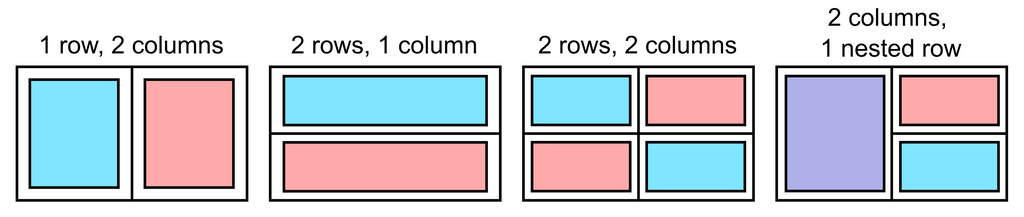

Example plot arrangements that can be accomplished with the `ggpubr` package.

```r
# Adjust our plot window size according to the expected output
options(repr.plot.width=20, repr.plot.height=20)

# Arrange the two plots in a single page
ggarrange(..., ...,
          labels = c("A", "B"),
          ncol = ..., nrow = ...)
```

## 6.2.0 Arrange plots within plots

Next we will add in the boxplot by nesting a `ggarrange()` call within another.

Imagine a square with 4 boxes.

1. We are going to place our line graph across the top row (top 2 boxes)
2. We'll place our age group data in the bottom left box
3. We'll drop our marginal plot into the bottom right box

To do this, we are arranging 2 rows (one with the line graph and one with the [age group + marginal plot], `nrow = 2`) and we are arranging 2 columns in the bottom row (one with the age group and one with the marginal plot, `ncol = 2`).

```r
# Adjust our plot window size according to the expected output
options(repr.plot.width=20, repr.plot.height=20)

# Arrange the two plots in a single page
ggarrange(phu_cases.plot, # row 1 plot
          # row 2 plots
          ggarrange(..., ...,
                    labels = c("B", "C"),
                    ncol = 2,
                    nrow = 1
                   ),
          # finish specifying characteristics of the two-row arrangement
          labels = c("A"),
          ncol = 1,
          nrow = 2
         )
```

## 6.3.0 Small changes can be made with `align` and `font()`

Okay, there are a few problems with this arrangement.

**Problem 1**: Spacing aside, our title in plot B has spread over into area C. If you wanted to keep it, you would have to fix up the text in the plot and try again. However, we can treat the plots much like their own data and keep altering them with the `+` symbol. That means for a quick fix, we *could* just remove the title altogether. Do you remember how to access the plot title?

**Problem 2**: the x-axes in our B/C plots don't line up well. Would it look better if they did? If y-axis lines or x-axis lines are not aligned, this can be fixed with a call to `align = "v"` or `align="h"`.

**Problem 3**: the font labels denoting each plot look a little small overall. We can change this aspect with the `font.labels` parameter.

If you wanted to make sure all axis titles are the same size you can specify these small changes using `font()`. You can try to access these attributes through simple names like "axis.title", and "legend.title" ie `font("axis.title", size=9)` but you need to set *each graph and each attribute separately*.

Let's drop our plot B title, and try to shore up the axes between B and C. Unfortunately we may be stopped by the crowded spacing at the bottom of these plots.

```r
# Adjust our plot window size according to the expected output
options(repr.plot.width=20, repr.plot.height=20)

plot <-

# Arrange the two plots in a single page
ggarrange(phu_cases.plot,
          ggarrange(demographics.plot + ..., ### 6.3.0 remove the title
                    phu_marginal.plot,
                    labels = c("B", "C"),
                    ncol = 2,
                    nrow = 1,
                    ... = list(size=20), # make the labels larger
                    align = "h" # Try to align the x-axis of both plots
                   ),
          labels = c("A"),
          ncol = 1,
          nrow = 2,
          ... = list(size=20) # Match the increased label size of the other plots
         )
plot

ggsave(plot, file = "Lec03.ggarange.png", width = 20, height = 20, unit = "in")
```

## 6.4.0 Determine significance levels for your plots with `ggpubr`

One last tool that you might find useful in your plots is the addition of significance levels or p-values to your plots. Since we've already loaded the `ggpubr` package, we'll use a function for pair-wise comparisons called `stat_pwc()` which will allow us to perform a limited analysis of our data.

Before continuing, we should take a look at the `compare_means()` function to see how `ggpubr` performs its analyses. This function, like other modeling functions (eg think `lm()`) can accept a formula based on your variables from a specific set of data. In our case, we'd like to see how, within each age group, the percent cases compares to the percent hospitalizations.

The `compare_means()` functions has a few relevant parameters to help us out:

- `formula`: the formula we use to define our dependent variable as a function of our independent
- `data`: the data set you will be using
- `method`: the type of comparisons you'd like to make as either comparing means directly (`t.test` or `wilcox.test`) vs omnibus tests (`anova` or `kruskal.test`).
- `ref.group`: a character string or numeric value denoting which group the other comparisons are to be made against (think in terms of a control group!)
- `group.by`: a character vector stating which additional variables you'd like to use in grouping your data. This is used for grouped plots!
- `p.adjust.method`: how you'd like to correct for multiple comparisons (eg. bonferroni, hommel, hochberg, BH, etc)

Let's try out the `compare_means()` function on our COVID-19 demographics data.

```r
covid_demographics_total.df %>%
# Ungroup this dataframe to clean it up a little
ungroup() %>%
# Filter for cumulative data
filter(period == "cumulative") %>%
# Select for just the important columns
select(public_health_unit, age_group, percent_cases, percent_hospitalizations) %>%
# Pivot the modified table to capture the "stat_group" of percent_cases vs percent_hospitalizations
pivot_longer(cols=c(3,4), names_to = "stat_group", values_to = "percent_PHU_total") %>%

# Compare the means of our groups within the data
compare_means(formula = ...,
              data = .,
              group.by = ...,
              p.adjust.method = "hochberg")
```

### 6.4.1 Use `geom_pcw()` to add significance levels to your plots

Now that we've seen how `compare_means` generates output, we can use this knowledge to add pairwise comparison significance levels *directly* to our plots using the ggplot-friendly layer `geom_pcw()` which will essentially annotate our plot with the levels.

This function shares many of the same parameters as `compare_means()` with a few additions:

- It does not take a formula but rather generates one based on your aesthetics mappings of `x`, `y` and other factors.
- `mapping`: the same kind of mapping parameters as all other geom layers, this let's us set some aesthetics - most importantly the `group` aesthetic.
- `y.position`: the y-axis value at which we want to display our significance values. This can be a single value or a vector of values to represent each comparison.
- `method`: here the choice of methods differs and they come from the `rstatix` package including `wilcox_test`, `t_test`, `dunn_test`, and `tukey_hsd`
- `method.args`: a list of additional arguments that are needed for the test method. For instance `tukey_hsd` will require a model object (eg `lm` or `aov`) to determine its comparisons.
- `label`: this determines the source of the labels for your plot. They can include `p.adj`, `p.format`, and `p.signif` as well as an expression using the syntax we have already learned.

There are many additional parameters generally for tweaking *how* the data is displayed. You can find a list of these over on the [ggpubr reference] (https://rpkgs.datanovia.com/ggpubr/reference/geom_pwc.html)

Let's add the Wilcoxon comparisons from our above analysis directly to our grouped violin plots.

```r
# Adjust our plot window size according to the expected output
options(repr.plot.width=20, repr.plot.height=12)

comparison_groups <- list(c("20-39", "40-59"), c("60-79", "80+"))
# comparison_groups <- list(c("percent_cases", "percent_hospitalizations"))

# Build and save the plot for later use
demographics.plot <- covid_demographics_total.df %>%
# Ungroup this dataframe to clean it up a little
ungroup() %>%
# Filter for cumulative data
filter(period == "cumulative") %>%
# Select for just the important columns
select(public_health_unit, age_group, percent_cases, percent_hospitalizations) %>%
# Pivot the modified table to capture the "stat_group" of percent_cases vs percent_hospitalizations
pivot_longer(cols=c(3,4), names_to = "stat_group", values_to = "percent_PHU_total") %>%
# filter(stat_group == "percent_cases") %>%

# Plot the data as a grouped violin plot with inset boxplot

# 1. Data
ggplot(.) +
    # 2. Aesthetics
    aes(x=age_group, y = percent_PHU_total) +

    # Start with a base theme
    theme_minimal() +

    theme(text = element_text(size=20), # set text size to 20

          # Move the legend around to within the panel space
          legend.justification = c(0,1),
          legend.position = c(0.02,0.95),
          legend.direction = "horizontal",

          # Update the panel to drop the minor axis grid lines
          panel.grid.minor = element_blank(),

          # Use a black line for the axes
          axis.line = element_line(colour = "black"),
          axis.text = element_text(colour = "black", face="bold"),
         ) +

    # Add labels to the plot
    labs(title = "Percent cases and hospitalizations by proportion per PHU across age group",
         x = "\nAge group",
         y = "Proportion of reported PHU data\n",
         caption = "\n*Age group values are calculated as a percentage of total cases or hospitalizations within a PHU") +

    ### Use the guides() layer and get rid of the scale_fill_discrete() layer
    guides(fill = "none", group = "none") +

    # 3. Scaling
    scale_y_continuous(limits = c(0, 0.6)) +         # Set the limits of our y-axis

    # Set the labels of our x-axis categories
    scale_x_discrete(labels=c("0-4", "5-11", "12-19", "20-39", "40-59", "60-79", "80+")) +

    # Set the colour legend
    scale_colour_discrete(name = "Data category", labels = c("% cases", "% hospitalizations")) +

    # 4. Data
    # multi-factor violin plots but keep the width consistent

    ### 3.4.0 Link your fill to the colour aesthetic
    geom_violin(scale="width",
                aes(colour = stat_group, fill=after_scale(alpha(colour, 0.3))),
                lwd = 1.5) +

    # Boxplot but smaller width so they reside "within" the violin plot
    geom_boxplot(aes(fill = stat_group), width=0.2,
                 position = position_dodge(width=0.9),
                 outlier.shape=NA) + # Remove the outliers

    # Add in all of the data points
    geom_quasirandom(dodge.width = 0.85, aes(group=stat_group), alpha = 0.8) +

    ### 6.4.1 Add in signifcance values to your plot
    geom_pwc(mapping = ...,    # Set the grouping to use stat_group (like group.by)
             method = "wilcox_test",               # Use a non-parametric test
             label = ..., label.size = 10,  # Label with significance levels instead of p-values
             y.position = c(0.2, 0.2, 0.2, 0.45, 0.45, 0.5, 0.5))  # Reposition the y-axis location of individual labels

# Show the plot
demographics.plot
```

# 7.0.0 Class summary

Today we have dug deep into altering and playing with our plots to help get them to that extra level. Although there is far more to explore, this should cover *most* of your needs when it comes to cleaning up your plots. To recap, we've looked at:

1. Altering themes and element positions.
2. Controlling/substituting values and labels.
3. Colour palettes.
4. Annotating plots with additional geoms.
5. Text-based formatting changes.
6. Generating Multi-plot figures.

Looking a little bit ahead at this week's assignment, you will look at canada-wide vaccination data.

[output not shown]

## 7.1.0 Weekly assignment

This week's assignment will be found under the current lecture folder under the "assignment" subfolder. It will include a Jupyter notebook that you will use to produce the code and answers for this week's assignment. Please provide answers in markdown or code cells that immediately follow each question section.

|  | Assignment breakdown |  |
| --- | --- | --- |
| Code | 50% | - Does it follow best practices? |
|  |  | - Does it make good use of available packages? |
|  |  | - Was data prepared properly |
| Answers and Output | 50% | - Is output based on the correct dataset? |
|  |  | - Are groupings appropriate |
|  |  | - Are correct titles/axes/legends correct? |
|  |  | - Is interpretation of the graphs correct? |

Since coding styles and solutions can differ, students are encouraged to use best practices. Assignments *may* be rewarded for well-coded or elegant solutions.

You can save and download the Jupyter notebook in its native format. Submit this file to the the appropriate assignment section by 9:59am on the March 28th, 2023 (Yes, even though we don't have class that day).

## 7.2.0 Acknowledgements

**Revision 1.0.0**: created and prepared for **CSB1021H S LEC0141**, 03-2021 by Calvin Mok, Ph.D. *Bioinformatician, Education and Outreach, CAGEF.*

**Revision 1.0.1**: edited and prepared for **CSB1020H S LEC0141**, 03-2022 by Calvin Mok, Ph.D. *Bioinformatician, Education and Outreach, CAGEF.*

**Revision 1.0.2**: edited and prepared for **CSB1020H S LEC0141**, 03-2023 by Calvin Mok, Ph.D. *Bioinformatician, Education and Outreach, CAGEF.*

## 7.3.0 References

The R Graph Gallery: https://www.r-graph-gallery.com/index.html

Different aesthetics parameters in `ggplot()`: https://ggplot2.tidyverse.org/reference/aes_group_order.html

Which aesthetics can be altered for different geoms?: https://ggplot2.tidyverse.org/reference/aes_linetype_size_shape.html

Advanced examples of direct labeling with `geom_dl()`: https://directlabels.r-forge.r-project.org/examples.html

More information about the `gghighlight` package: https://cran.r-project.org/web/packages/gghighlight/vignettes/gghighlight.html

Using `expression()`: https://stat.ethz.ch/R-manual/R-devel/library/grDevices/html/plotmath.html

Using `bquote()`: https://www.r-bloggers.com/2018/03/math-notation-for-r-plot-titles-expression-and-bquote/

More options for `ggarrange()`: https://rpkgs.datanovia.com/ggpubr/reference/ggarrange.html

Learning some of the functions for `ggExtra`: https://cran.r-project.org/web/packages/ggExtra/vignettes/ggExtra.html

## The Center for the Analysis of Genome Evolution and Function (CAGEF)

The Centre for the Analysis of Genome Evolution and Function (CAGEF) at the University of Toronto offers comprehensive experimental design, research, and analysis services in microbiome and metagenomic studies, genomics, proteomics, and bioinformatics.

From targeted DNA amplicon sequencing to transcriptomes, whole genomes, and metagenomes, from protein identification to post-translational modification, CAGEF has the tools and knowledge to support your research. Our state-of-the-art facility and experienced research staff provide a broad range of services, including both standard analyses and techniques developed by our team. In particular, we have special expertise in microbial, plant, and environmental systems.

For more information about us and the services we offer, please visit https://www.cagef.utoronto.ca/.

[figure not shown]